# Kapitel 16 Psykofarmakologi

Här beskrivs allmänna principer och särskilda psykofarmakologiska aspekter. Val av behandling vid olika diagnoser beskrivs istället i kapitlet för respektive diagnos.

## 16.1 Allmänna principer

- Nytta vs risk
- Karlägg tidigare respons/icke-respons
- Förstagradssläktingars respons på visst läkemedel
- Följsamhet

### 16.1.1 Halveringstid, utsättning, byte mm

Se “Psychotropic Drugs With Long Half-Lives: Implications for Drug Discontinuation, Occasional Missed Doses, Dosing Interval, and Pregnancy Planning” [178].

Halveringstiden för de flesta antidepressiva är kring 24 tim, vilket medger dosering 1 gång per dygn. Steady state uppnås efter ungefär fem halveringstider. Tmax är 1-5 tim för de flesta.

Undantag, tex:

- Venlafaxin (Thalf 5h or 11 for active metabolite; Tmax 2.5h or 7h for XR)
- Agomelatin Thalf 1-2h?
- Vortioxetin halflife 60h
- Fluoxetin: The half-life of fluoxetine is 1–3 days, and that of its active metabolite norfluoxetine is 7–15 days.11,12 The half-life of fluoxetine may increase during maintenance therapy because fluoxetine inhibits its own metabolism.

Vid byte av tex antidepressiva bör balanseras:

- Risken för utsättningssymtom vid låga nivåer av läkemedlet
- Risken för överdosering/biverkningar (tex serotonergt syndrom)

Resonemang:

Vid byte blir utsättningssymtomen sannolikt relaterade till skillnader i receptorprofil.

Kanske mindre besvär att byta mellan två SRI. Kan möjliggöra tvärt byte (undantag fluoxtin).

Vid byte till preparat med helt annan receptorprofil (tex till/från bupropion, mirtazapin, agomelatin) kanske risken för utsättningssymtom är större. En möjlig strategi är att halvera preparat A i en vecka, sedan sätta in preparat B parallellt i halvdos en vecka, sedan avslut A och måldos B.

Vid byte från fluoxetin kanske avslut en vecka, sedan starta läkemedel B?

Vid byte från venlafaxin, kvarstå på det (i halv dos?) tills 3-4 halveringstider för preparat B passerat?

## 16.2 Metabolism av psykotropa läkemedel

Metabolismen av de flesta psykotropa läkemdel påverkas av cytokrom P450-systemet, samt andra enzymer och transportproteiner. Individuella skillnader i dessa (polymorfismer) kan påverka läkemedlens metabolism och interaktioner mellan läkemedel som påverkar (indeucerar, hämmar, eller metaboliseras av-) dessa system. Dock finns inte vetenskapligt stöd för att analys av individuella variationer i tex CYP-450 enzymer har någon klinisk användning. En delförklaring kan vara att de flesta läkemedel metaboliseras av flera CYPar.

För antidepressiva finns inte vetenskapligt stöd för att genotypning av CYP-450-enzymer skulle ha någon kliniska användbarhet. Det finns ej någor klart påvisat samband mellan CYP-genotyp och serumkoncentrationer, ej heller något klart påvisat samband mellan CYP-genotyp och effekt eller biverkningar [179]. Se [154] avsnitt om TCA.

**Rökning** kan påverka metabolismen av psykotropa läkemedel. Exempelvis reduceras nivåerna av agomelatin, vissa bensodiazepiner, klozapin, duloxetin, haloperidol, olanzapin, och TCA [50].

**Alkohol** kan påverka metabolismen av psykotropa läkemedel. Exempelvis kan nivåerna av aripiprazol, bensodiazepiner, klozapin, haloperidol, mirtazapin, kvetapin, risperidon, TCA och venlafaxin initialt bli högre pga kompetetiv metabolism med alkohol via CYP3A4. Induktion av detta enzym pga alkohol (kvarstår veckor efter avslutat alkoholintag) kan därefter leda till ökad metabolism av dessa läkemedel med minskad behandlingsffekt som följd [50].

## 16.3 Mätning av plasmakoncentrationer

Monitoring: [180]

### 16.3.1 Antidepressiva

Det finns inte något vetenskapligt stöd för att definiera ett “terapeutiskt fönster” som kan tillämpas på individnivå. En möjlig orsak till detta är metodologiska problem i des tudier som gjorts (suboptimala mätmetoder, bristande följsamhet hos vissa, olika genes till depression, svårt att definiera respons pga olikheter i symtom, måttlig efficacy för AD - stora material krävs).

Trots olikheter mellan individer avseende metabolism av lökemedel saknas för antidepressiva läkemedel för ett samband mellan plasmakoncentration och respons [181]. Mätning av serumkoncentrationer kan möjligen ha ett värde vid icke-respons, biverkningar vid normala doser, misstanke om låg följsamhet, interaktioner och vid graviditet (nivåerna av SSRI kan minska). Extremt låga eller -höga koncentrationer kan då möjligen vara vägledande (tex sertralin < 10 ng/mL kanske reducerad effekt?, sertralin > 150 ng/mL kanske ökad risk för toxicitet?), men terapeutiska referensintervall saknas. Vid behandling med TCA kan koncentrationsbestämning ibland vara av värde för att undvika toxiska nivåer [182]. För en diskussion se [183].

Möjligen kan mätning av förändring i serumkoncentration över tid på individnivå vara användbart i vissa fall [183].

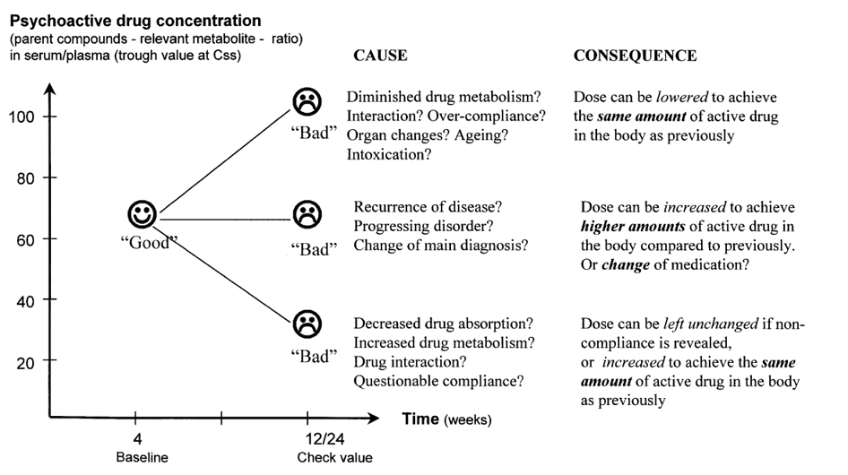

Figur 16.1: Mätning av serumkoncentration av antidepressiva medel över tid hos en individ. Uppföljande prov (12v) jämförs med baslinjeprov (4v).

### 16.3.2 Antipsykotiska medel

Situationer där mätning av plasmakoncentrationer kan ha värde [184]:

1. Uncertain adherence to antipsychotics
2. No clinical response within established therapeutic dose ranges
3. Symptom recurrence or relapse during maintenance treatment
4. Adverse drug reactions (ADRs)
5. Combination treatment with medication(s) with inducing or inhibiting properties
6. Genetic peculiarities for the pathways involved in the metabolism of antipsychotics (the prevalence of specific genetic variants affecting drug metabolism may vary highly in different ethnic groups, eg, Caucasian versus Asian, middle Eastern vs the rest of the world)
7. Patients with abnormally high or low body weight or body mass index
8. Pregnant or lactating patients
9. Child or adolescent patients
10. Elderly patients
11. Patients with intellectual disabilities
12. Forensic patients or court mandated individuals as the treatment of this patient subgroup presents special challenges that underscore the need for tracking and mitigating nonadherence
13. Patients with pharmacokinetically relevant comorbidities, such as hepatic or renal dysfunction and severe cardiovascular disease (affecting hepatic and renal blood flow)
14. Patients with acute or chronic inflammatory conditions and infections
15. Postoperative care for patients undergoing restrictive gastrointestinal resection or bariatric surgery
16. Switching between the original preparation and generic forms of antipsychotics due to potential therapeutic equivalence differences, as well as related adherence aspects
17. Switching between oral antipsychotics and LAIs
18. Pharmacovigilance programs
19. Research

Effect of CYP2D6 genotype on exposure and efficacy of risperidone and aripiprazole: a retrospective, cohort study [185].

| Drugs and active metabolite | Therapeutic reference range (ng/mL) | Laboratory alert level (ng/mL) |
| --- | --- | --- |
| Clozapine | 350–600 | 1000 |
| Fluphenazine | 1-10 | 15 |
| Haloperidol | 1-10 | 15 |
| Perphenazine | 0.6-2.4 | 5 |
| Olanzapine | 20-80 | 100 |
| Aripiprazole | 100-350 | 1000 |
| Paliperidone | 20-60 | 120 |
| Risperidone + 9-hydroxyrisperidone | 20-60 | 120 |

Mätning av koncentration görs före morgondosen av läkemedlet vid steady-state (efter 4-5 halveringstider). Se [184] för tabell med fler AP, halveringstider mm.

### 16.3.3 Läkemedel vid bipolärt syndrom

För vissa läkemedel som används vid bipolärt syndrom finns ett värde i att mäta plasmakoncentrationer. Se avsnitt 8.3.7 och för litium avsnitt 16.8.

## 16.4 SSRI vid graviditet och amning

Barn vilkas mammor använt SSRI under förlossning får oftare för tidig födsel, lägre födslovikt, autism och ADHD [186]. Detta kan bero på att depression är genetiskt kopplat till dessa tillstånd, vilket innebär att mammor som är deprimerade oftare har en genetisk uppsättning som också är förknippat med ADHD eller autism. En annan delförklaring kan vara större förekomst av riskfaktorer såsom rökning och alkoholbruk. Det kan också bero på att depressionen i sig är skadlig för barnet. En annan tänkbar förklaring är att de läkemedel som ges vid depression påverkar fostret.

Potentiella risker med SSRI-behandling skiljer sig åt mellan olika delar av graviditeten. Exempelvis befaras att vissa SSRI under tidig graviditet kan öka risken för medfött hjärtfel. Riskökningen är dock liten. SSRI-behandling under senare delen av graviditeten kan ge utsättningssymptom hos barnet och eventuellt öka risken för pulmonell hypertension hos barnet.

Angående risken för ADHD och autism har en stor svensk studie visat att det inte föreligger någon ökad risk för autism eller ADHD [186]. Man såg även att om barnets pappa använde antidepressiva, eller om mamman använt antidepressiva *före* graviditeten, ökade risken för ADHD och autism, vilket talar för att det är familjefaktorer snarare än läkemedlen som orsakar den ökade risken för dessa tillstånd.

Mycket litet av läkemedlen finns i bröstmjölken. Som försiktighetsåtgärd avråds från SSRI under amning, men riskerna är troligen mycket små och får vägas mot behovet.

> “Citalopram, escitalopram, and sertraline appear to be the safest selective serotonin reuptake inhibitors during pregnancy, whereas fluvoxamine, paroxetine, and sertraline are preferred in breastfeeding women because they lead to the lowest serum medication levels in breastfed infants.” [90]

Av mammor som står på antidepressiva före graviditet och väljer att fortsätta får 20% återfall under graviditet, jämfört med 35% (CI 19-60%) av de som väljer att avsluta. Det är osäkert om denna skillnad är statistiskt signifikant[188].

För att illustrera risker och fördelar med antidepressiv behandling, se tabellen nedan som visar ett ungefärligt exempel på incidens av depression respektive missbildningar hos barnet för 1000 fullgångna graviditeter (siffrorna motsvarar antal individer):

[output not shown]

Förenklat: Om man behandlar 100 mammor med graviditetsdepression kommer 10 fler att slippa depression och 1 ytterligare barn födas med en missbildning, jämfört med om man avstår behandling. Om man behåller profylaktisk behandling med antidepressiva hos 100 mammor kommer 15 fler (CI 0-40) att slippa depression och 1 ytterligare barn födas med en missbildning.

Andra psykofarmaka:

- Kontraindicerade: Karbamazepin, Valproat.
- Kan användas: Olanzapin, Risperidon, Kvetiapin, Klozapin.

### 16.4.1 Risker för barnet

Följande potentiella risker har identifierats: Missbildningar, persisterande pulmonell hypertension (andningsbesvär i anslutning till förlossningen), Poor adaptation, Premature birth, Intrauterine growth retardation, Neonatal adaptive syndrome

Persisterande pulmonell hypertension: Risk utan AD 1.2/1000, med AD 3/1000, OR 2.1 (1.5-3).

Djurstudier visar att manlig avkomma till mödrar som intagit fluoxetin har negativ testikelpåverkan[189].

#### 16.4.1.1 Missbildningar hos barnet

I en analys av mer än 800.000 graviditeter (N = 848 786 graviditeter, 843 797 icke-exponerade, 806 pausade SSRI, 4 183 fortsatte SSRI) [190] fann man en liten riskökning vid antidepressiv behandling. Dock var risken hos de som pausade sin behandling under graviditet också troligen förhöjd (för litet antal fall för att avgöra säkert).

Risk of any major malformation in SSRI use

| Group | N | Case,n | Incidens % | OR* |
| --- | --- | --- | --- | --- |
| Unexposed | 843797 | 29703 | 3.5 | Ref |
| Paused | 806 | 36 | 4.5 | 1.27 (0.91 to 1.78) |
| Continued | 4183 | 208 | 5.0 | 1.33 (1.16 to 1.53) |
| Sum | 848786 | 29947 | 3.5 | - |

*Multivariabel logistisk regression justerad for ålder, paritet, inkomst, utbildning, rökning och konceptionsår.

Förenklat: Missbildning 3 på 100 födslar hos friska och 4-5 födslar hos de som tar ssri.

### 16.4.2 Risker för mamman

Depression prevalens 12% under andra och tredje trimestern. Totalt prevalens depression vid graviditet ca 20%?. Post partum depression prevalens 15%.

Högre risk för preeklampsi och eklampsi vid depression.

Effekt av antidepressiv behandling vid graviditetsdepression: I en metaanalys[191] (K=11, N=1016) fann man respons på SSRI hos 55%, jämfört med 43% med placebo (RR CI 0.97 to 1.66); remission 42% vs 27% (RR CI CI 0.99 to 2.41) och minskade symtom (SMD −0.30, CI −0.55 till −0.05).

Se [192]

### 16.4.3 Utsöndring av SSRI i bröstmjölk

1. Fluoxetin
2. Citalopram/escitalopram
3. Paroxetin
4. Sertralin
- Sällan > 8ng/ml serumkonc. Högst 3% av moderns viktjusterade dygnsdos
- Försumbar effekt på serotonintransport hos barnet
5. Fluvoxamin

Symtom som kan förekomma (risken anses liten):

- Skrikighet, sömnproblem, oro, myoklonus

Inga belägg för byte av behandling. Vid nyinsättning ge SSRI med låg passage till bröstmjölk

### 16.4.4 Resurser

NHS patient recommendations: https://www.nhs.uk/conditions/ssri-antidepressants/considerations/#pregnancy

Associations of Maternal Antidepressant Use During the First Trimester of Pregnancy With Preterm Birth, Small for Gestational Age, Autism Spectrum Disorder, and Attention-Deficit/Hyperactivity Disorder in Offspring [186]

## 16.5 Antidepressiva läkemedel

Se tabell 42-1 (farmakokinetik), 42-2 (receptorbindning) och 42-3 (polysomnografiska effekter) i [154].

### 16.5.1 Likheter bland de flesta antidepressiva

- Lipofila
- Snabb absorbtion
  - Maximal plasmakoncentration efter 2-3 tim
- Binds i hög grad till plasmaproteiner
- Hepatisk metabolism till metaboliter
- Renal elimination av metaboliter
- Hämmar minst en av CYParna

### 16.5.2 Verkningsmekanismer

I stort sett alla antidepressiva har gemensamt att de påverkar monoaminsignalleringen i hjärnan (och andra delar av kroppen). Hämning av serotoninåterupptaget via SERT är gemensamt för de flesta antidepressiva16.2. Den sk “monoaminhypotesen”, att depression orsakas av en obalans i monoaminer i hjärnan, ligger till grund för forskningen som lett till framtagandet av antidepressiva medel. Uppfattningen att det rör sig om “serotoninbrist” saknas det stöd för, vilket varit känt sedan länge[193]. I grunden vet man därför inte varför antidepressiva läkemedel har antidepressiv effekt. Eftersom en mekanisktisk förklaring av orsakerna till depression saknas är det rimligt att anta att effekten av antidepressiva endast till viss del överlappar symtomen vid depression. För en kritisk diskussion om “drug centered” respektive “disease centered” modell för förståelse om hur psykofarmaka verkar, se[194]. En intressant observation är att exempelvis en sederande effekt av vissa antidepressiva kan påverka skattningen av depression, även om kärnsymtomen inte nödvändigtvis påverkas. Omvänt kan biverkningar av antidepressiva (tex gastrointestinala problem) medföra en försämrad skattning ev deras effekt.

### 16.5.3 Olikheter i receptorprofil

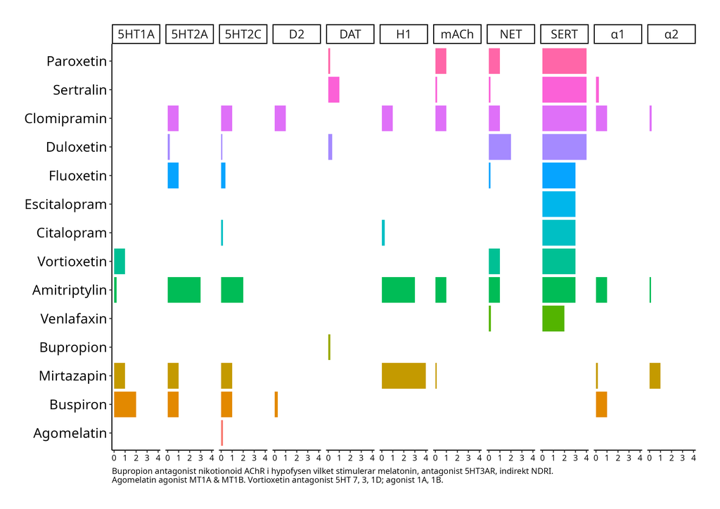

Figur 16.2: Antidepressiva läkemedels affinitet till vissa receptorer

### 16.5.4 Finns dos-respons?

- Effektiviteten för SSRI ökar i intervallet 20-40 mg fluoxetinekvivalenter
  - Däröver planar ut eller **minskar** [57,58]
  - Induktion av metabolism, saturation av receptorer, biverkningar
- Tolerabilitet minskar (fler drop-outs) vid ökande doser i hela dosintervallet [58]
- Det finns minimalt vetenskapligt stöd för att öka dosen av ett SSRI när man tittar på totalpoängen för HDRS.
  - Kan påverka symtomet nedstämt humör positivt
- Sammanfattningsvis är låga till måttliga doser av SSRI optimala [59].
- Terminologi:
  - “Minsta effektiva dos”: Sämre effekt under denna
  - “Maximal effektiv dos”: Där effektvinsten planar ut, “respons maximum”
  - “Optimal dos”: Balans mellan effekt och biverkningar

**Tabell 16.1** nedan visar minsta effektiva dos (sämre effekt under denna) och högsta effektiva dos (ej ökad effekt öve denna) för olik antidepressiva [50,57,195–197].

Tabell 16.1: Minsta effektiva dos och dos som ger maximal respons för antidepressiva läkemedel. Asterisk* = Möjligen finns dos-respons upp till respons maximum.

| Läkemedel | Min effektiv dos | Respons maximum |
| --- | --- | --- |
| Citalopram* | 20 | 40 |
| Escitalopram* | 10 | 20 |
| Fluoxetine | 20 | 20 |
| Paroxetine | 20 | 20 |
| Sertraline* | 50 | 100 |
| Desvenlafaxine | 50 | 50 |
| Duloxetine | 60 | 60 |
| Venlafaxine* | 75 | 150 |
| Agomelatine* | 25 | 60 |
| Mirtazapine* | 15 | 30 |
| Vortioxetine* | 10 | 20 |
| Amitriptyline | 125 |  |

### 16.5.5 Tricykliska antidepressiva

Tertiära tricykliska medel (imipramine, clomipramine, trimipramine, amitriptyline, butriptyline, doxepin, dosulepin) är mer sederande än sekundära (nortriptyline, protriptyline, and desipramine) tricykliska medel [154]. Tertiära TCA har relativt sett mer effekt på SERT och sekundära mer på NET.

Omkring 7% av befolkningen har en variant av CYP2D6 som leder till långsammare metabolism av tricykliska medel och därmed ger upp till 30-faldig ökning av plasmakonentrationen. Högre ålder medför minskad metabolisering via CYP3A4 samt minskad renal clearance.

### 16.5.6 Bupropion

Antidepressant Drugs Effects on Blood Pressure [198]

## 16.6 Antipsykotiska läkemedel

Klinisk effekt av antipsykotiska läkemedel har påvisats vid 65-90% bindning till D2-receptorn och risken för motoriska biverkningar ökar vid en bindningsgrad på 80% (vilket ses vid ungefär 6 mg/d för risperidon, 30 mg/d för olanzapin, och 160 mg/d för ziprasidone). D2 occupancy optimum kan vara 65% [199].

### 16.6.1 Receptoraffinitet

[figure not shown]

Figur 16.3: Antipsykotiska läkemedels affinitet för olika receptorer.

### 16.6.2 Doseringsintervall

Tabell 16.2 visar relativa doseringsintervall för några antipsykotiska läkemedel [10,50].

Tabell 16.2: Doseringsintervall för antipsykotiska läkemedel.

| Läkemedel | Minsta effektiva dos | Måldos | Max effektiv dos | Maxdos |
| --- | --- | --- | --- | --- |
| Kariprazin | 1.5 | 1.5 | 6 | 6 |
| Haloperidol | 2.0 | 2.0 | 10 | 20 |
| Risperidon | 2.0 | 4.0 | 10 | 16 |
| Flupentixol | 4.0 | 4.0 | 8 | 18 |
| Olanzapin | 5.0 | 10.0 | 20 | 20 |
| Aripiprazol | 10.0 | 15.0 | 15 | 30 |
| Klozapin | 25.0 | 300.0 | 450 | 900 |
| Lurasidon | 37.0 | 37.0 | 148 | 148 |
| Ziprasidon | 40.0 | 40.0 | 160 | 160 |
| Kvetiapin | 150.0 | 600.0 | 800 | 800 |

Måldos bör i allmänhet vara vara minsta effektiva dos för att minimera biverkningar. Minsta effektiva dos är den dos under vilken effekten sannolikt är begränsad. Max effektiv dos är den dos över vilken ytterligare effekt ej kan förväntas. Dessa doseringar gäller vid psykos. Vid depression och bipolärt syndrom kan andra måldoser gälla.

I en metaanalys (K=26, N=4776) av läkemedelsbehandling vid schizofreni såg man att effektkurvan för återfallsrisk var hyperbol för de flesta antipsykotiska medel och att den planade ut vid 5-mg/d risperidonekvivalenter[200]. Exempelvis var återfallsrisken (under ca ett år) 67% för placebo, 57% för 1 mg risperidonekvivalenter, 47% för 2 mg, 38% för 3 mg, 32% för 4 mg, 30% för 5 mg. För patienter som var i remission vid baslinje planade effektkurvan ut tidigare (2.5 mg risperidonekvivalenter), likaså för FGA (3 mg). Man fann liknande resultat vid akut schizofreni[201].

Denna referens[201] innehåller även dos-responskurvor för individuella antipsykotiska medel (Fig 2 i artikeln). Effekten ser ut att plana ut vid SMD 0.6 (0.4 för negativa symtom) för de fleasta AP, vissa har ej undersökts i tillräckliga doser för att se utplaningen. För olanzapin och klozapin ses ingen tydlig utplaning och ökningen av SMD tycks fortsätta mer linjärt åtminstone till SMD 0.8-1. Kvetiapin och brexipiprazol planar ut vid SMD 0.3; kariprazin och asenapin vid SMD 0.4.

The ED95 is the dose required to achieve the desired effect in 95% of the population.

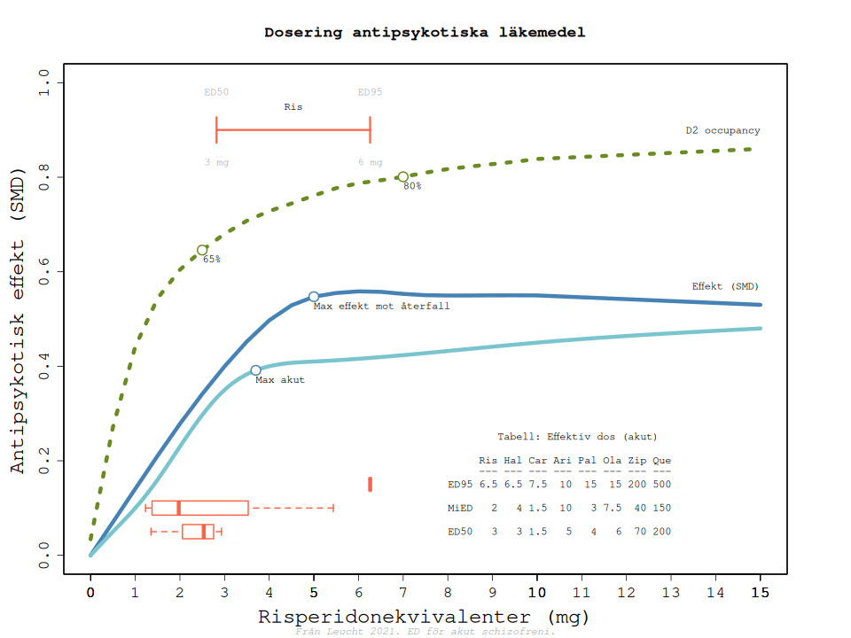

Tabell: Förenkling av doser för ED50 ED95 vid 6 mg.

| Läkemedel | Min | Mål |
| --- | --- | --- |
| Ris | 3 | 6 |
| Hal | 3 | 6 |
| Car | 1.5 | 6 |
| Ari | 5 | 10 |
| Pal | 5 | 15 |
| Ola | 5 | 15 |
| Zip | 50 | 200 |
| Que | 200 | 500 |

[Konverteringskalkylator doser](https://lvhjmo.org/calc/)

### 16.6.3 Biverkningar översikt

Figur 16.4 visar grovt den relativa risken för olika typer av biverkningar av antipsykotiska läkemedel. Många av biverkningarna är dosberoende. Källa: Maudsley.

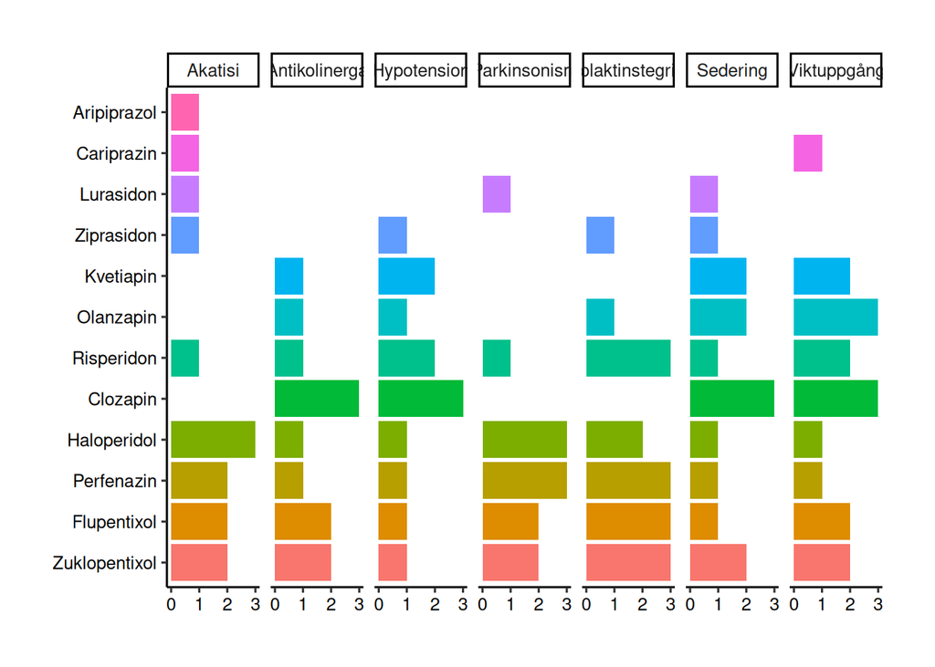

Figur 16.4: Relativ risk för biverkningar av antipsykotiska läkemedel

### 16.6.4 Motoriska biverkningar

- Dosberoende
  - Smalt terapeutiskt intervall
- Anses vanligare med FGA
  - …men doseringen har stor betydelse
- Mindre vanligt med:
  - Klozapin, olanzapin, kvetiapin
  - Aripiprazol

Riskfaktorer:

- Drogbruk (dystoni, akatisi, TD)
- Alkohol (akatisi)
- Ålder, kön

Referens [50]

Tabell: Ungefärlig incidens av motoriska biverkningar

| Biverkan | % | Debut |
| --- | --- | --- |
| Akut dystoni | 0.4 | t-d. 50% inom 48h, 95% 5d |
| Katatoni | 0.005 | t-d |
| MNS | 0.002 | t-d |
| Parkinsonism | 10 | d-m. 50% inom 1m, 90% 3m |
| Akatisi | 30 | d-m. 50% inom 1m, 90% 3m |
| Tardiv dyskinesi | 24 | m-år. 5% per år |
| Tardiv dystoni | 2 |  |

Ungefärlig incidens vid användning av första generationens antipsykotiska medel. Debut räknas från tiden för start eller dosökning av ett antipsykotiskt läkemedel. Förkortningar: t, timmar; d, dagar; m, månader

Förekommer även utan AP, vid obehandlad schizofreni: Dystoni 1%, dyskinesi 9% (vid längre duration), parkinsonism 8% (17% vid längre duration), akatisi 11%

#### 16.6.4.1 Länkar till filmer med motoriska biverkningar

[Film motoriska biverkningar](https://www.youtube.com/watch?v=ucrV4ljDKuE)

[Film motoriska biverkningar $\ExternalLink$](https://www.youtube.com/watch?v=2xfu-d_aYWs)

[Parkinsonism $\ExternalLink$](https://www.youtube.com/watch?v=7SyTpEdhBLw)

[Tremor vid parkinsonism $\ExternalLink$](https://www.youtube.com/watch?v=pUL0Amkq4Ok)

[Tardiv dyskinesi $\ExternalLink$](https://www.youtube.com/watch?v=FUr8ltXh1Pc)

#### 16.6.4.2 (Akut) Dystoni

Muskelspasm i någon kroppsdel

- Kontinuerlig eller intermittent
- Oftast nacke, huvud, och bål
- Kan vara smärtsam
- Duration sek-tim; 24-48 tim efter avslut
- Debut 95% inom 5d

Exempel:

- Oculogyrus (ögonen dras uppåt)
- Torticollis (huvud och nacke dras åt sidan)
- Dysfagi (sväljsvårigheter)
- Dysartri (sluddrigt tal, talsvårighet)
- Trismus (grimasering) $\rightarrow$ tungan ut
- Blefarospasm (hopknipna ögon)

Riskfaktorer:

- Ung man
- Ingen tidigare AP-behandling
- Högpotenta AP (tex haloperidol)

#### 16.6.4.3 Katatoni

- Symtom
  - Muskelrigiditet
  - Orörlighet
  - Mutism
  - Strirrande blick
  - mm
- Variant: Exciterad katatoni
  - Psykomotorisk agitation
- Förlopp
  - Debut inom tim-dagar
  - Kan fluktuera
- Skattning: Bush-Francis

#### 16.6.4.4 Malignt neuroleptikasyndrom

Kombination som (hos 70%) uppträder i följande ordning:

1. Förändrat mentalt status (82%)
   - Konfusion, delirium, katatoni, mutism
   - Senare stupor, koma
2. Muskelstelhet
   - Generaliserad
   - Ofta mkt uttalad
3. Feber > 38 (87%)
   - Ev ej lika vanligt vid SGA
4. Autonom dysfunktion
   - Takycardi (88%)
   - Labilt eller högt blodtryck
   - Takypné (73%)

Debut inom tim-dagar. Dessa symtom enskilt kan förekomma som biverkan av AP, men kombinationen talar för NMS. Om >1 av dessa symtom, överväg NMS.

#### 16.6.4.5 Parkinsonism

Vanliga symtom:

- Bradykinesi
  - Svårt starta rörelser
  - Långsamma rörelser
  - Utslätat ansiktsuttryck
  - Monoton röst
  - Kort steglängd
  - Minskad medrörelse armar
- Postural tremor, “långsam” (3-6 Hz)
- Ökad muskeltonus (rigiditet, kugghjulsfenomen)
- Dysfagi (sväljsvårigheter), salivering
- Debuterar efter dagar-veckor-månader
- Skattningsskala: Simpson-Angus

#### 16.6.4.6 Tardiv dyskinesi

Symtom:

- Vanligast med rörelser kring munnen, tungan
  - Smackande, tuggande
  - Utstickande tunga
- Andra kroppsdelar
  - Choreatoida handrörelser, “pianospel”, “pillertrillande”
  - Ryckiga rörelser i nacke, händer, höfter, ben
- Kan ge svårigheter med tal, matintag, andning
- Kan förvärras av stress
- Gradvis debut efter 3 månader eller mer
- Reversibelt hos 50%, oftast *inte helt* reversibelt
- Skattning: Abnormal Involuntary Movements Scale (AIMS)

Riskfaktorer[202]:

- Ålder >50 (2-5 ggr ökad risk), kvinna (ffa äldre kvinnor)
- Affektiv sjukdom (bipolär, äldre studier med FGA)
- Intellektuell funktionsnedsättning
- Diabetes mellitus
- Alkoholbruk
- Andra motoriska biverkningar (parkinsonism, akatisi, dystoni, låggradig dyskinesi)
- Intermittent behandling
- Första generationens antipsykotiska medel[203,204]
  - Bland SGA kan aripiprazol och olanzapin medföra lägst risk.

Risken för TD är ungefär 5% per år med FGA, hälften med SGA och kanske lägre än så med olanzapin eller aripiprazol.

#### 16.6.4.7 Akatisi

Kan även uppträda när AP *sätts ut* eller reduceras

- Inre känsla av rastlöshet
  - Ofta i benen
  - …eller hela kroppen
  - Svårt att sitta stilla, trampar med fötterna, gungar fot till fot
  - Ofta mycket obehagligt
- Kan ge avvikande rörelsemönster
- Vanligen debut inom två veckor
  - Kan uppträda några dagar efter start av behandling
  - 50 % debuterar inom 1 mån
  - 90 % debuterar inom 3 mån
- Skattningsskala: Barnes Akathisia Scale

#### 16.6.4.8 Behandling av motoriska biverkningar

| Biverkan | Sätt ut | Reducera | Byt | Antikolinergikum |
| --- | --- | --- | --- | --- |
| Dystoni | Ja | Nej | Ja | God effekt |
| Parkinsonism | (Ja) | Ja | Ja | Har effekt |
| Akatisi | (Ja) | Ja | Ja | EJ effekt |
| Tardiv dyskinesi | Ja | Nej | Ja | Kan försämra |

Antikolinerga läkemedel: Biperiden (akineton)

- Dystoni: Effekt inom 5 min för iv, inom 20 för im
- Parkinsonism: **Begränsad tid**, ompröva var 3:e mån, **ej nattetid**

##### 16.6.4.8.1 Ytterligare behandling

Dystoni:

- ECT, (rTMS?)
- Botulinumtoxin

Akatisi:

- Propranolol 30-80 mg/d
- Klonazepam (låg dos)
- 5-HT antagonister
  - tex mirtazapin, diphenhydramin, cyproheptadin
- Sätt ut SSRI (kan ge akatisi, kan påverka metabolism av AP)

Tardiv dyskinesi:

- Sätt ut antikolinerga läkemedel
- Byt till AP med mindre benägenhet för TD (dock motstridiga data)
  - Klozapin, kvetiapin mest sannolikt hjälpsamt
- Valbenazin, deutetrabenazin [finns ej i Sverige?]
- Klonazepam
- Ginkgo biloba?

Ref [50]

### 16.6.5 Metabola biverkningar

> “Marked differences exist between antipsychotics in terms of metabolic side-effects, with olanzapine and clozapine exhibiting the worst profiles and aripiprazole, brexpiprazole, cariprazine, lurasidone, and ziprasidone the most benign profiles.”[205]

Incidensen av metabolt syndrom det första året med behandling är 10% (aripiprazol, ziprasidon, haloperidol, perfenazin) till 50% (olanzapin, risperidon, kvetiapin).

#### 16.6.5.1 Viktuppgång

Tabell: Ranking (störst till minst)[66].

| Rank | Läkemedel | Viktuppgång medel, kg |
| --- | --- | --- |
| 1 | Klozapin | 10 |
| 2 | Olanzapin | 8 |
| 3 | Klorpromazin | 7 |
| 4 | Kvetiapin | 4 |
| 5 | Risperidon | 4 |
| 6 | Aripiprazol | 0 |
| 7 | Haloperidol | 0 |
| 8 | Flufenazin | 0 |
| 9 | Ziprasidon | 0 |
| 10 | Perfenazin | 0 |

#### 16.6.5.2 Metabola syndromet

Medför särskilt ökad risk för typ 2 diabates och hjärt-kärlsjukdom.

[Se internetmedicin](https://www.internetmedicin.se/endokrinologi-och-diabetologi/metabola-syndromet)

Diagnosticeras om:

1. Bukfetma
- Hos kvinnor är midjemått > 80 cm, hos män > 94 cm.
2. Samt minst 2 av följande:
- Triglycerider > 1,7 mmol/l
- HDL < 1,3 mmol/l för kvinnor, < 1,0 mmol/l för män
- Blodtryck > 130/85 mm Hg eller blodtrycksbehandling
- Faste-P-glukos > 5,6 mmol/l eller IGT (nedsatt glukostolerans) eller diabetes mellitus typ 2

#### 16.6.5.3 Åtgärder

Rökstopp, kost, motion

“Metformin may be effective in preventing weight gain (MD −4.03 kg, 95% CI −5.78 to −2.28; 4 studies, 131 participants; low‐certainty evidence); and BMI increase (MD −1.63 kg/m2, 95% CI −2.96 to −0.29; 5 studies, 227 participants; low‐certainty evidence).”[206]

Se även [207].

### 16.6.6 Hematologiska biverkningar

Se [208]

Sällan kliniskt signifikanta.

Mekanismer:

1. Direkt benmärgshämning (toxicitet)
2. Anikroppar mot hematopoetiska stamceller
3. Destruktion av perifera celler

Vanligast är neutropeni, eosinofili, trombocytopeni.

Monitorering: Efter insättning/doshöjning, månad 3, 6, 12, därefter årligen (?)

Is monitoring needed? https://pubmed.ncbi.nlm.nih.gov/31210059/

Kan påverka alla tre cellinjer (röda blodkroppar, vita-, och trombocyter).

| Tillstånd | Incidens | Klozapin | Utredning |
| --- | --- | --- | --- |
| Anemi |  |  |  |
| Trombocytopeni |  |  |  |
| Neutropeni | 1/10.000 | 1/50 |  |
| Agranulocytos | <1/1000 | 1/100? |  |
| Aplastisk anemi |  |  |  |
| Eosinofili |  | 1/500 |  |
| Trombocytos |  |  |  |
| Hemolytisk anemi |  |  |  |
| Leukocytos | 4/100 (risp) |  |  |

Neutropeni:

- Incidens: 1/10 000 för phemotiaziner; 1/50 för klozapin
- Åtgärd: Sätt ut läkemedlet och följ. Vid svår neutropeni eller infektion, akut omhändertagande.
- Förlopp: Gradvis debut. Avklingar 3-4 v efter utsättning.
- Uppföljning: Följ NEU 1 gång/vecka tills normaliserat

Eosinofili:

- Förlopp: Uppträder inom 4v från start
- Risker: Hypereosinofila syndrom med organpåverkan
- Åtgärd: Sätt ut läkemedlet

Trombocytopeni:

- Läkemedel: Fera olika neuroleptika, tex klorpromazin, prochlorperazine, thioridazin and klozapin
- Allvarliga blödningar ses nästan bara vid TPK < 10

Trombocytos:

- Läkemedel: Klozapin

Hemolytisk anemi:

- Fallrapporter: Kvetiapin, aripiprazol

Pancytopeni:

- Fall: Clozapine, quetiapine and risperidone

TTP-HUS:

Fall: Quetiapine

Anamnes:

- Blödningshistoria: Näsblödning, Blodblåsor i munnen, Andra slemhinneblödningar, Hematuri, Melena, Menses - Menorragier, lung-/GI-/cerebrala blödningar
- Autoimmun sjukdom
- Helicobacter pylori
- Hematologiska B-symtom? (feber, nattliga svettningar och viktnedgång)?
- Naturläkemedel
- Vaccinationer?
- Alkoholöverkonsumtion?

Status:

- Hudblödningar. Petekier, pupura är konfluerande petekier. Vanligen på underbenen
- Munhåla/svalg. Petekier, blodblåsor.
- Patologiskt förstorade lymfkörtlar
- Buk: förstorad lever eller mjälte.

Provtagning för utredning

- Hb
- TPK
- LPK
- MCV
- Ret
- LD: Lätt till måttligt förhöjt LD hos 50% av de med ITP. Significant elevations are seen in various malignancies, tissue necrosis, haemolytic anaemia, ineffective erythropoiesis, liver disease, nephrotic syndrome and muscular disorders
- Haptoglobin: Hemolytisk anemi
- 5-part
- Folat
- B12
- Elstat
- Lever
- Thyr
- Vid tromboctopeni: ANA, PK, INR, Hcy, elfores, HP-serologi

https://onlinelibrary.wiley.com/doi/full/10.1111/bjh.16183

### 16.6.7 Olika typer av antipsykotiska läkemedel

Gemensamt: Alla blockerar dopamin-2-receptorn

- Vissa blockerar (& aktiverar) den *partiellt*
  - Tex aripiprazol, kariprazin, norklozapin
- Olika stark bindning till D2-receptorn, tex:
  - Aripiprazol = stark
  - Klozapin = svag
- Olika snabb dissociation från D2-receptorn
  - Kvetiapin = snabb

Skiljer: Effekt på andra receptorer

- Antikolinerga effekter
- Antihistaminerga effekter
- Anti alfa-adrenerga effekter
- Effekt på serotoninreceptorer
  - 5HT2C inversa agonister: Klozapin, olanzapin, risperidon
  - 5HT2C partiell agonist: Aripiprazol
- Effekt på andra dopaminreceptorer

Framför allt andra generationens AP har effekt på flera receptorer.

#### 16.6.7.1 “Första generationen” aka “Typiska”

- **Haloperidol** (Haldol)
- **Perfenazin** (*Trilafon*)
- **Zuklopentixol** (Clopixol, *Cisordinol Depot*)
- **Flupentixol** (Fluanxol, *Fluanxol Depot*)
- **Klorprotixen** (Truxal)

*kursiv* = Depotinjektion, ges men några veckors mellanrum

#### 16.6.7.2 “Andra generationen” aka “Atypiska”

- **Klozapin** (Leponex)
- **Risperidon** (Risperdal, *Risperdal Consta*, *Risolept Consta*)
- **Paliperidon** (Invega, *Trevicta*, *Xeplion*)
- **Ziprasidon** (Zeldox)
- **Olanzapin** (Zyprexa, *Zypadhera*)
- **Kvetiapin** (Quetiapin, Seroquel, depottablett)
- **Lurasidon** (Latuda)

#### 16.6.7.3 Partiella agonister

- **Aripiprazol**: Abilify, *Abilify Maitena*
- **Kariprazin**: Reagila

#### 16.6.7.4 Se referenser

Effectiveness of Antipsychotic Drugs in Patients with Chronic Schizophrenia lieberman [209].

Randomized Controlled Trial of the Effect on Quality of Life of Second- vs First-Generation Antipsychotic Drugs in Schizophrenia [210].

The CATIE and CUtLASS studies in schizophrenia: results and implications for clinicians [211].

Inga skillnader mellan grupperna (SGA vs FGA) i fråga om livskvalitet eller symtom.

### 16.6.8 Kombinationsbehandling

Clozapin + aripiprazol?

Andra kombinationer?

### 16.6.9 Switching

Se tabell på [psychiatrinet](https://wiki.psychiatrienet.nl/wiki/Main_Page).

## 16.7 Psykotropa läkemedel vid leverpåverkan

Ref [212]

De flesta psykotropa läkemedel metaboliseras av levern.

Nedsatt leverfunktion påverkar:

- Absorbtion (förändringar i gastrointestinalt blodflöde pga stas)
- Första-passage metabolism (inkl biotranformering)
- Oral biotillgänglighet kan vara ökad (pga utdragen biotransformation, metabolism och elimination)
- Shuntning förbi levern
- Ökad extracellulärvolym vid ödem och ascites (vattenlösliga läkemedel, tex litium)
- Minskad koncentration av plasmaproteiner (tex albumin). Leder till en förskjutning av kvoten fritt/bundet läkemedel för läkemedel med hög proteinbindningsgrad vilket kan göra att mätningar av läkemedelskoncentration kan feltolkas (om totalmängden mäts kanske denna inte speglar den fria fraktionen)

### 16.7.1 Anpassning av läkemedelsdoser

Allmänna tumregler:

- Om ASAT och ALAT är förhöjt men < x3 ULN kan de flesta psykotropa läkemedel fortsätta användas.
- Ge lägre startdos och trappa upp långsammare.
- Läkemedel med komplex metabolism eller där det skapas aktiva metaboliter i levern (tex amitriptylin, imipramin, vanlafaxin, bupropion) kan vara svårhanterade.
- Läkemedel med lång halveringstid (ex fluoxetin, aripiprazol) eller slow-release medför mer oförutsägbar faramkokinetik och bör därför undvikas.
- Vid känd leverpåverkan kontrollera förutom AST/ALT även bilirubin, albumin, och undersök förekomst av ascites och encefalopati.

Vid känd leversjukdom eller ASAT/ALAT > x3 kan Child-Pugh-klassifikationen vara vägledande (egentligen till för prognosticering).

Tabell: Child-Pugh klassifikationen

| Poäng | 1 | 2 | 3 |
| --- | --- | --- | --- |
| Encefalopati | Ingen | Grad 1-2 | Grad 3-4 |
| Ascites | Ingen | Lätt | Svår |
| Bilirubin* | < 35 mikromol/L | 35-51 mikromol/L | > 51 mikromol/L |
| Albumin | > 35 g/L | 28-35 g/L | < 28 g/L |
| PK | < 1,7 | 1,7-2,3 | > 2,3 |

Tolkning: Child-Pugh A: 5-6 poäng; Child-Pugh B: 7-9 poäng; Child-Pugh C: 10-15 poäng. Femårsöverlevnaden är vid Child-Pugh A 80 %, Child-Pugh B 50 % och Child-Pugh C 35 %.

Bilirubin har andra gränser vid PBC: < 68 mikromol/L, 68–171 mikromol/L, respektive > 171 mikromol/L.

| Child-Pugh gradering | Leversvikt | Dosering (% av standard) |
| --- | --- | --- |
| A | Mild | 75-100% |
| B | Måttlig | 25-50% |
| C | Svår | Konservativt, monitorera |

Sammanfattningsvis innebär detta att vid kände leversvikt eller AST/ALT > x3 men frånvaro av ascites, hypoalbuminemi och med normalt bilirubin och PK, kan 75-100% av normaldosen användas.

#### 16.7.1.1 Vid leversvikt undvik läkemedel med…

- Komplex metabolism eller aktiva metaboliter skapas i levern
  - Tex amitriptylin, imipramin, venlafaxin, bupropion
- Lång T1/2 eller slow-release (oförutsägbar faramkokinetik)
  - Tex fluoxetin
- Hög grad förstapassage-metabolism
  - TCA, venlafaxin, sertralin
- Hög grad proteinbindning
  - Fluoxetin
- Högst risk för leverpåverkan
  - Imipramin, amitriptylin, duloxetin, bupropion, agomelatin, venlafaxin
  - Mirtazapin ger sämre lever-prognos? [213]
- Risk för allvarlig toxicitet (dock ovanligt)
  - Duloxetin

### 16.7.2 Leverpåverkan från psykotropa läkemedel

- Vanligen ALAT > ASAT

Mekanismen kan vara metabol eller allergisk. Laoratoriebilden hepatocellulär, kolestatisk eller blandad.

Risk för mild till måttlig påverkan: karbamazepin, valproat, vissa TCA, SNRI, atypiska antipsykotiska.

Antidepressiva: Leverpåverkan hos ca 1%, vanligare hos äldre och vid polyfarmaci. Vanligen ej dosberoende. Uppträder vanligen inom dagar upp till 6 månader efter start. Högst risk med imipramin, amitriptylin, duloxetin, bupropion, agomelatin. Lägst risk med citalopram, escitalopram, paroxetin, fluvoxamin.

Risk för allvarlig toxicitet (dock ovanligt): Duloxetin, karbamazepin, valproat (1 på 20.000).

Antidepressant-induced liver injury: a review for clinicians voican 2014 [214]

“For safety reasons, when using an antidepressant associated with a greater risk of hepatotoxicity (iproniazid,nefazodone, phenelzine, imipramine, amitriptyline, duloxetine, bupropion, trazodone, tianeptine, or agomelatine) or prescribing an antidepressant for a patient with an underlying liver disease, regular monitoring of serum ALT should be discussed, even though there is no formalrecommendation for such investigations. For agomelatine, assessment of liver function is recommended for all patientsbefore treatment and again after 3, 6, 12, and 24 weeks oftreatment (151). Nevertheless, further studies are neededboth to confirm the efficacy of follow-up liver function testsfor the early detection of DILI and to identify patients atgreater risk of DILI.” [214]

“antidepressants should be discontinued immediately in any patient with suspected DILI. It has been suggested that these drugs should be promptly discontinued when serum ALT levels are x3 ULN (or x 5 ULN, as recently suggested) (9) or if there is an unexplained increasein bilirubin levels to x 3 ULN. For patients with high baseline ALT levels, drug discontinuation is recommended whenserum ALT levels are x 3 times the baseline value.” [214]

Se även [215].

Drug-induced liver injury (DILI) kan delas upp i två typer:

1. Intrinsic DILI.
- Dosberoende
- Kort latens
2. Idiosyncratic DILI
- Ovanligare
- Oftast ej dosberoende
- Mer variation i manifestation, svårare

## 16.8 Litium

Litium används främst vid bipolärt syndrom typ I men även vid bipolärt syndrom typ II och vid unipolär depression. Huruvida litiumbehandling har indikation vid olika tillstånd beror på om det används som profylax eller som behandling av ett pågående skov, samt på episodens typ (mani eller depression).

En fördel med litium är att det finns lång klinisk erfarenhet och att biverkningarna kan ses som lindriga jämfört med alternativen (tex antipsykotiska medel). Vid bipolärt syndrom typ I är litium det enda läkemedlet med dokumenterad effekt på både den maniska (stark dokumentation) och depressiva fasen (svagare dokumentation), både som akutbehandling och profylax, samt det enda läkemedlet med vetenskapligt stöd för antisuicidal effekt. Litiumbehandling kräver monitorering med blodprover var 4:e till 6:e månad.

Verkningsmekanismen oklar. Sannolik mekanism är att Litium uppreglerar gener som kodar för cellskyddande proteiner och celltillväxt så att hjärncellerna blir fler, starkare och mer stabila (den neuroprotektiva hypotesen).

### 16.8.1 Effekt av litium vid BD[216]

- 60% av patienter med mani eller depression förbättras (>50% reduktion)
- 25% med blandad episod får positiv respons
- 50% bibehåller remission (olika studielängd)

Effektstorlek 1.7 för depression (0.8 RCT; 1.9 NRT) Effektstorlek 1.9 för mani (1.5 RCT; 3.5 NRT)

#### 16.8.1.1 Litium profylax RCT[122]

- Any episode: RR 0.66, 95% CI 0.53 to 0.82
- Mani: RR 0.52, 95% CI 0.38 to 0.71
- Depression: RR 0.78, 95% CI 0.59 to 1.03

### 16.8.2 Effekt av litium vid unipolär depression[217]

Tabell: Evidens från RCTer av litium vid unipolär depression[217]

| Situation | Monoterapi/tillägg | K | N | Effekt |
| --- | --- | --- | --- | --- |
| Akut MDD | Mono | 6 | 218 | Nej (jfr AD eller pbo) |
| Akut MDD | Tillägg till AD | 12 | 541 | OR 2.3, CI 1.6–3.5, p<0.0001 |
| Profylax MDD | Mono | 7 |  | OR 4.5, CI 1.4–15, p 0.011 |
| Profylax MDD | Tillägg till AD | 9 |  | OR 2.4, CI 1.0–5.4, p 0.038 |

Dock bör biverkningsrisken vägas in[218]. Har antisúicidal effekt vid BP eller MDD.

Litium särskilt rekommenderas vid[219]:

- Svår depression med suicidrisk (antisuicidal effekt)
- Svår depression
- > 3 depressiva episoder
- Viktförlust
- Psykomotorisk hämning
- Förstagradssläkting med MDD eller BP.
- Efter ECT

Målkonc:

Lägre gräns: 0.4 to 0.6 mEq/L, de flesta studier 0.5–0.6 mEq/L Övre gräns: 0.6 to 1.2 mEq/L Förslagsvis: 0.5-0.7

Vid utsättning bör litium trappas ned gradvis över tre månader för att minska risken för relaps.

### 16.8.3 Historik

Cade testade litium på marsvin som skydd mot ureatoxicitet och noterade sedering som effekt.

Trautner 1955 The excretion and retention of ingested lithium and its effect on the ionic balance of man [220].

Trautner om toxicitet

### 16.8.4 Indikationer

Li har fått ökat vetenskapligt stöd för behandling av bipolär sjukdom på senare år, bland annat när det använts som jämförelseläkemedel i långtidsstudierna av lamotrigin. Används också som tilläggsbehandling för unipolär depression, för att förebygga cykloid psykos och provas ibland mot borderlinetillstånd och patologisk impulsivitet. Antisuicidal effekt vid bipolärt syndrom.

Senast (2010) som Socialstyrelsen rekommenderade något vad gäller bipolär sjukdom. För att förebygga återfall efter en manisk eller depressiv episod bör hälso-och sjukvården erbjuda: läkemedelsbehandling med litium (prioritet 1); läkemedelsbehandling med tillägg av psykologisk behandling med KBT (prioritet 2); patientutbildning (prioritet 3) och närståendeutbildning (prioritet 3) som komplement till återfallsförebyggande läkemedelsbehandling.

Litium kan även användas vid unipolär depression. Personer med täta depressiva skov liknar bipolärt syndrom i fråga om hereditet, debutålder, atypiska symtom och profylaktisk respons på litium[95]. Det finns flera små randomiserade, kontrollerade och blindade studier av litiumprofylax mot recidiv av unipolär depression (totalt n = 229). De visade samantaget att 75 % fick recidiv med placebo och 36 % med litiumbehandling[221]. Recidiverande depression kan således vara en indikation för profylaktisk litiumbehandling. Efter behandling av unipolär depression med ECT har litium troligen en liten till medelstor effekt (weighted OR of 0.53, CI = 0.34, 0.82), liknande den vid profylax efter uni- eller bipolär episod som ej behandlats med ECT[222].

Tecken på sämre effekt vid affektiva blandtillstånd (mixed state). Detta gäller dock även annan behandling,

[Response to litium network](https://rlink.eu.com/)

### 16.8.5 Biverkningar

Tabell: Biverkningar av litium (ungefärlig incidens)[223]

| Biverkan | Frekvens | Dos | Minskar | Åtgärd |
| --- | --- | --- | --- | --- |
| Någon biverkan | 75% |  |  |  |
| Viktuppgång (M 4 kg) | 70% | Ja? |  |  |
| Ökad törst | 70% |  | Ja |  |
| Polyuri | 70% |  | Nej | Hydroklortiazid, kvällsdos |
| Sexuell dysfunktion | 40% |  |  | Sildenafil |
| Acne | 40% |  |  |  |
| Leukocytos | 40% |  |  | 1/5 övergående |
| Tremor | 25% | Ja | Ja | Propranolol, B6, kvällsdos |
| Illamående | 15% |  | Ja |  |
| Struma | 30% |  |  |  |
| Subklinisk hypothyreos | 20% |  |  | Thyroxin om TSH >10 |
| Hypothyreos | 15% |  |  | Thyroxin |
| Hyperthyreos | 1% |  |  | Mb Graves förekommer |
| Hyperkalcemi | 25% |  |  |  |
| Hyperparathyroidism | 10% |  |  |  |
| Parkinsonism | 15% |  | Ja |  |
| Myoklonus | 10% |  | Ja |  |
| Dyskinesi | 10% |  | Ja |  |
| Diarre | 10% |  | Ja | Litiumkarbonat |
| Perifera ödem | 10% |  |  |  |
| Psoriasis | 5% |  |  |  |
| Akatisi | 1% |  | Ja |  |
| Trötthet |  |  |  |  |
| Ökad aptit |  |  |  |  |
| Kognitiva besvär |  |  |  | Modafinil? |
| SILENT (konfusion, stupor) |  |  |  | Irreversibel ataxi |
| Ataxi |  |  |  |  |
| Kronisk njursvikt | ovanligt |  |  | Ev vid >10å beh |

> A rare, probably irreversible, syndrome acronymized as SILENT (Syndrome of Irreversible Lithium-Effectuated Neurotoxicity) involving persisting cerebellar dysfunction with ataxia or unsteady gait has been reported in a few cases (Aditanjee et al. 2005)[100].

Tremor

- Låg dos propranolol
- Hög dos vitamin B6
- Dosreduktion

Polyuri

- Hydroklortiazid 50 mg (ökar litiumkonc, reducera dosen med 1/3, ny konc efter 3d, följ kalium)
- Amilorid 5 mg bid

Movement disorders[224]

#### 16.8.5.1 Thyroideapåverkan[225]

- Minskar syntes och frisättning av T3 och T4
- Ökar risken för thyroidea-autoimmunitet

Hypothyreos

- Diagnosticeras efter 18m (medel), men kan uppstå inom några månader
- Vanligare (50%) om positiva TPO-antikroppar
- Vanligare hos kvinnor, ålder >50, och hereditet för thyroideasjukdom

Hyperthyreos och thyroidit

- Oftast i samband med smärtfri, övergående thyroidit (Följs ofta av hypothyreos)
- Förekommer även granulomatous thyroidit, lymphocytisk thyroiditi

> Baseline and regular assessment of thyroid function tests (TSH, free T4); thyroid size using thyroid ultrasonography and measurement of titres of auto-antibodies against thyroid peroxidase is recommended among patients prior and during lithium therapy.

> Patients with lithium induced hyperthyroidism are best treated with anti thyroid drugs like carbimazole with/without steroids. Radioiodine or thyroidectomy should be reserved for patients with lithium induced Graves’ disease especially in cases of poor compliance to the anti thyroid drugs. In cases of a toxic nodular goitre with/without compressive symptoms, a thyroidectomy is indicated. In cases of lithium induced thyroiditis, ablative radioiodine is not indicated because of its poor uptake. Conservative management with regular follow up is recommended in such cases since majority of the patients develop hypothyroidism subsequently

#### 16.8.5.2 Kontraindikationer[100]

- Hjärtinfarkt
- Akut njursvikt
- Brugada syndrom, ventrikulär arytmi

Försiktighet vid[100]:

- Arytmi
- Njursvikt
- Psoriasis
- Myeloid leukemi
- Addison
- Hypothyreos
- Neurologisk sjukdom (texmyasteni, epilepsi, parkinson)

#### 16.8.5.3 Intoxikation

Toxisk i höga koncentrationer (uttorkning, njursjukdomar, feber, överdosering).

Intoxikation. Vaksamhet för litiumförgiftning vid nivåer över 1.3 mmol/l. 1.5-2.5 mmol/l ger lindrig– måttlig intoxikation med symtom av slöhet, tremor, yrsel, sluddrigt tal, diarré, muskelryckningar. Koncentrationer därutöver ger allvarlig intoxikation med risk för konfusion, agitation, njurskador, hallucinationer, kramper, koma och hjärtrytmrubbningar. För att undvika intoxikation ska alla patienter instrueras att tillfälligt utsätta Litium under några dagar vid risk för intorkning eller minskad njurfunktion (dvs hög feber, njursjukdom, svår diarré, vattenbrist). De ska instrueras att aldrig ta andra mediciner utan att fått dessa ordinerade av läkare som känner till att de tar Litium (paracetamol går bra).

> Abnormally high blood levels of lithium (above 1.5 mEq/L) can increase risk of intoxication, signs of which are severe tremor, confusion, vomiting, abdominal pain, diarrhea, abnormally increased reflexes, speech difficulties, abnormal heart rhythm, hypotension, and convulsions[100].

2.5-3.0 mEq/L potentially dangerous even in the absence of toxic symptoms [226]

#### 16.8.5.4 Effekter på njuren

> Renal lithium toxicity is characterized by increased water and sodium diuresis, which can result in mild dehydration, hyperchloremic metabolic acidosis and renal tubular acidosis. The concentrating defect and natriuretic effect develop within weeks of lithium initiation. [227]

> Long-term lithium therapy is associated with impairment of urinary concentrating ability in up to 50% of patients with polyuria of greater than 3 liters per 24 hours in 20% of patients (Boton et al. 1987). Such increased urine volume carries a potential risk to the patients because of sodium depletion, excessive fluid loss, or reduced intake. In 5 to 10% of patients, the impairment of urinary concentrating ability may be irreversible or only partly reversible upon lithium discontinuation […] In contrast, glomerular function remains relatively unscathed. Johnson et al. (1984) found a mild-to-moderate decrease in 15% of patients, with a fall in glomerular filtration rate (GFR) correlated with age. They concluded that progressive impairment of glomerular and tubular function during lithium maintenance is related more to age, episodes of lithium intoxication, and concurrent drug administration, than it is to duration of lithium treatment [228].

> Lithium-induced CKD occurs mostly in patients who have been receiving lithium for more than 10–20years; occasionally, renal insufficiency develops earlier (within 10 years of lithium initiation) [227]

#### 16.8.5.5 Vid graviditet och amning

Ger ökad risk för hjärtmissbildningar under första trimestern. Går över i bröstmjölk. Bör användas under graviditet och amning endast efter särskilt övervägande.

### 16.8.6 Farmakokinetik

Litium är ett grundämne och metaboliseras inte. Det utsöndras till 95% i urinen (övrigt via svett och faeces). Faktorer som påverkar exkretion och retention av natrium (tex blotryck, njurperfusion/reglering av afferenta arteriolerna) påverkar också eliminationen av litium. Detta är den viktigaste faktorn för variation över tid i litiumlimination för en viss individ. Efterson litium leder till polyuri finns en särskild risk för retention av natrium vid dehydrering. Koncentrationen i hjärnan är ungefär hälften av den i blodet, och är endast svagt korellerad till serumkoncentrationen. Litium uppvisar ett linjärt doskoncentrationssamband, d v s, dubbel dos ger dubbel koncentration. Toppkoncentration efter en dos uppnås för tablett med normal frisättning 1fter 1-2 tim och för tablett med långsam frisättning efter 4-5 tim. Biotillgängligheten är 80-100%, total clearance 10-40 mL/min och eliminationshalveringstiden 18-36 tim [229]. Steady state uppnås efter ca fem dygn.

Eliminering av litium via njurarna påverkas av:

- Osmotiska faktorer (vilka)
- Njurfunktion (GFR? Tubuli?)
- Interaktion med vissa läkemedel: NSAID, diuretika, ACE-hämmare.
- Eliminationen ökar mot slutet av graviditet
- Dehydrering, hjärtsvikt, och lågt saltintag minskar utsöndringen.

Vanligen mäts tolvtimmarsvärde, dvs litiumkoncentrationen tolv timmar efter en dos. Detta kan räknas om till ett uppskattat 24-tim värde (24 h värde x 1,6 = 12 h värde).

Litiumkinetiken i njurarna är enlig följande:

1. Andel som filtreras över glomerulära basalmembranet: 100%
2. Reabsorbtion i proximala tubuli: 80%
- Blockeras av amilorid
- Ökar av NSAID
3. Elimineras: 20% (20–40 mL/min eller 1/5 GFR)

Lithium nephrotoxicity revisited Grünfeld [227]

Lithium: updated human knowledge using an evidence-based approach [229]

Pharmacokineticsof LithiumJose de Leon, Utförlig föreläsning om Litium: https://inhn.org/fileadmin/user_upload/User_Uploads/INHN/Jose_de_Leon/29._Pharmacokinetics_of_lithium/De_Leon_1_-_29_Pharmacokinetics_of_lithium-_June_16__2016.pdf

### 16.8.7 Dosering i praktiken

Gå igenom sjukhistoria, aktuell läkemedelsbehandling och labbprover för att utvärdera om det finns kontraindikationer eller komplicerande faktorer (t.ex. njursjukdom, tidigare biverkningar av litium, hjärtsjukdom).

Informera patienten om biverkningar, interaktioner och symtom vid toxicitet.

Tag litiumprov tidigast sju dagar efter varje dosökning (men om S-Litium >0.7 nytt prov inom 3 dagar). Återbesök kan planeras ca tre dagar efter provtagning för dosjustering och kontroll av följsamhet och biverkningar. Om S-Litium >0.8 eller vid misstänka biverkningar kontaktas läkare för ställningstagande till dosjustering.

Starta med Lithionit 42 mg 1+0+1. Ökning sker med en veckas intervall, med en eller två tabletters ökning per tillfälle beroende på litiumkoncentration.

**Vid första uppföljning**, efter en veckas behandling

- Om S-Litium <0.21 öka Lithionit till 2+0+2.
- Om S-Litium 0.21-0.49 öka Lithionit till 2+0+1.
- Om S-Litium 0.5-0.69 (upp till 0.8 kan tolereras) fortsätt oförändrat med 1+0+1.

**Vid andra uppföljning**, efter ca två veckors behandling

- Om S-Litium <0.30 öka dosen med ytterligare 2 tabletter/dygn (uppdelat morgon och kväll).
- Om S-Litium 0.30-0.49 öka dosen med 1 tablett/dygn förutom om konc <0.4 och dosen är 2+0+2 då dosen höjs med 2 tabl/dygn (uppdelat morgon och kväll).
- Nytt S-Litium tas efter en vecka och återbesök ca 3 dagar därefter.

Vid akut mani kan litium ges med bolusdos för snabb upptrappning, tex 3+3 tabl i 2d => 2+3 i 2d => 2+2 i 2d. Följ litiumkoncentrationen. Obs att antimanisk effekt kräver högre målkoncentration. Kan sättas ut om pat ej vill fortsätta m litium.

**Fortsatta kontroller**

**Tillfälliga dosjusteringar i särskilda situationer**

- Halvera litiumdos inför ECT (minskar risk för postiktal konfusion), tex genom att hoppa över kvällsdosen dagen innan ECT.
- Interagerar med antiflogistika, tiaziddiuretika (ökar s-Li) och vissa hypertonimediciner (BBL, ACEi, CCB kan alla vara problematiska).
- Koffein ökar eliminationen (rekommendera ett stabilt intag)
- Känslig för försämrad njurfunktion.

### 16.8.8 Mer om litiumkoncentration

Det terapeutiska intervallet för litium är relativt väl etablerat, men någon tydlig konsensus finns inte. Högre Li-konc ger sannolikt bättre effekt upp till en viss gräns.

Lägre gräns: Under denna är en terpeutisk effekt osannolik.

Övre gräns: Över denna är en ökning av den terapeutiska effekten osannolik och tolerabiliteten minskar.

### 16.8.9 Monitorering

(P-Li och TSH var 4:e mån och årligen dessutom: P-Kreatinin, P-Ca, P-Albumin, P-glukos, BT och vikt).

Mätning av litiumkoncentration görs lämpligast 12 tim efter en dos. Vid singeldos är dock 24 tim bättre.

https://bpac.org.nz/magazine/2007/february/pdfs/bpj3_lithium_pages16-27_pf.pdf

### 16.8.10 Biverkningar

### 16.8.11 Toxicitet

Intoxikation. Vaksamhet för litiumförgiftning vid nivåer över 1,3 mmol/l. 1,5-2,5 mmol/l ger lin-drig – måttlig intoxikation med symtom av slöhet, tremor, yrsel, sluddrigt tal, diarré, muskelryck-ningar. Koncentrationer därutöver ger allvarlig intoxikation med risk för konfusion, agitation, njur-skador, hallucinationer, kramper, koma och hjärtrytmrubbningar.

## 16.9 Klozapin

Innehållet i detta avsnitt kommer huvudsaklineg från Clozapine Handbook [1].

### 16.9.1 Inledning

En stor andel (20-30 %) av personer med schizofreni får otillräcklig respons på två eller fler försök till behandling med antipsykotiska läkemedel. Klozapin har då bättre chans att ge effekt (>40 % respons jämfört med <5 % för andra antipsykotiska medel) än att ytterligare försök med andra antipsykotiska medel. De som behandlas med klozapin har lägre mortalitet och mindre behov av sjukhusvård. Om behandlingen med klozapin fördröjs mer än tre år minskar sannolikheten för behandlingseffekt. Detta gör att klozapin bör övervägas tidigt i förloppet vid behandlingsresistent schizofreni. Vid behandlingsresistent schizofreni bör följsamhet till behandling först undersökas genom mätning av plasmakoncentrationer av läkemedlet och behandlingsresistens bör särskiljas från intolerabilitet pga biverkningar.

Klozapin har även visad effekt mot:

- Psykogen polydipsi
- Suicidalitet (här är det bättre än tex olanzapin)
- Aggression
- Behandlingsresistent mani (i kombination med stämningsstabiliserande läkemedel)
- Bipolärt syndrom utan psykos
- Psykos vid Parkinsons sjukdom (i låg dos)

Dessa effekter är oberoende av den antipsykotiska effekten.

Klozapin medför risk för flera biverkningar, bland annat viktuppgång, men det är värt att notera att trots detta ger det lägre risk för död än andra alternativ.

### 16.9.2 Behandlingsresistent schizofreni

Klarlägg om verklig behandlingsresistens föreligger:

- Har två andra antipsykotiska preparat prövats i adekvat dos under adekvat tid?
- Föreligger följsamhet till behndling (kontrollera serumkoncentration)
- Föreligger biverkningar som förklarar vissa av personens kvarvarande symtom?

Vid otillräcklig effekt av klozapin:

1. Mät serumkoncentration vid upprepade tillfällen
- Fluktuationer > 50% föranleder misstanke om bristande följsamhet
- Serumkoncentrationen bör konsekvent ligga > 1070 nmol/L
2. Optimera dosen
- Titrera till högre serumkoncentration (upp till 3057 nmol/L) förutsatt att intolerabla biverkningar saknas
- Höj dosen med 2-3 veckors mellanrum
3. Lägg till ECT-behandling
4. Överväg tillägg av annat antipsykotiskt medel
- Vinsten med detta är osäker och effektstorleken låg (0.24)
- Välj preparat utifrån biverkningsprofil, eftersom någon skillnad mellan olika preparat ej kunnat visas (tex är aripiprazol lika effektivt som haloperidol i detta sammanhang).

### 16.9.3 Psykogen polydipsi

Psykogen polydipsi förekommer hos ca 20% av sjukhusvårdade med kronisk psykossjukdom. Klozapin har visat mycket god effekt mot detta vid dosen 300 mg/dag (i små studier).

### 16.9.4 Aggressivitet

Klozapin har effekt mot psykotisk aggressivitet (2) och effekten erhålls även om de psykotiska symtomen är oförändrade.

### 16.9.5 Behandlingsresistent mani

Det finns vetanskapligt stöd för att kozapin har effekt vid mani som ej svarat på annan behandling.

### 16.9.6 Psykos vid Parkinsons sjukdom

Mer än 50% av personer med Parkinsons sjukdom drabbas av sk “Parkinson’s disease psychosis” (PDP), som beror på förlust av serotonerga neuron i mesencephalon. Eftersom andra antipsykotiska medel orsakar motoriska problem för personer med Parkinsons sjukdom är klozapin att föredra, och är då effektivt i låga doser (medel kring 25 mg/d). Det kan även hjälpa mot levodopa-inducerade dyskinesier (med liknande dos).

### 16.9.7 Kontroller vid baslinje

Temperatur: Upp till 20% får benign feber under de första veckorna. Vid temp > 38 eftersök orsak och vänta med upptitrering.

Hjärtfrekvens: Takycardi är en vanlig biverkan. Undersök om hypovolemi föreligger. Kontrollera ett ortostatiskt prov. Vänta med upptitrering.

Blodtryck: Ortostatisk blodtryckreaktion är en vanlig biverkan. Undersök om hypovolemi föreligger. Kontrollera ett ortostatiskt prov vid yrsel. Vänta med upptitrering.

Vikt och BMI: Viktuppgång är vanligt. Obesitas är dock ingen kontraindikation. Klozapin medför lägre mortalitet trots viktuppgång.

Labbprover:

- Blodstatus inklusive absolut neutrofilnivå
- Njurfunktion (uteslut njursvikt, klozapin kan ge interstitiall nefrit)
- Leverprover (uteslut leversvikt)
- HBA1C (uteslut obehandlad diabetes mellitus)
- Lipidstatus (uppmärksamma bla triglyceridtsegring som metabol riskfaktor)
- EKG (QTT)
- Buköversikt om anamnes på förstoppning (uteslut aktuell förstoppning)

Anamnes:

- Rökning (påverkar klozapinkoncentrationen)
- Epilepsi (kan föranleda profylax i första hand med valproat)
- Förstoppning (måste behandlas före insättning av klozapin)
- Hjärtstvikt (måste behandlas före insättning av klozapin)

### 16.9.8 Monitorering under behandling

Prolaktin ökar ej av klozapin [230].

Vid hospitalisering pga somatisk sjukdom (särskil infektion) reducera dosen med 50%.

### 16.9.9 Titrering

Observera att ickerökare uppnär 50% högre koncentration än rökare vid samma dos. Rökning har därför betydelse för hur snabbt läkemedlet titreras.

Hela dosen kan ges till kvällen (up till 500 mg?). Trots en halveringstid på 9-17 tim är dosering till kvällen lika effektivt som uppdelade doser (metaboliten norklozapin har en halveringstid på 20 tim). Det är att föredra eftersom det minskar sedering dagtid.

Tabell 16.3 visar dosering med snabb upptitrering, som kan användas vid inneliggande vård.

Tabell 16.3: Snabb titrering av klozapin (för sjukhusvårdade)

[output not shown]

Tabell 16.4 visar dosering med normal upptitrering, lämpligt vid poliklinik behandling.

Tabell 16.4: Titrering av klozapin (för icke-sjukhusvårdade)

[output not shown]

Fortsatt titrering (50 mg per dosökning) styrs av klinisk respons (utvärderas 2-3 v efter dosändring) och plasmakoncentrationer. Tag första plasmakoncentration (dalvärde) 5-7 dagar efter att måldosen upnåtts. Notera at norklozapin ej uppnår steady state förrän efter en månad, varför monitorering av norklozapin blir meningsfull först när patienten stått på klozapin ett tag.

### 16.9.10 Serumkoncentrationer

Det finns en stor variation mellan individer i metabolismen av klozapin. Monitorering av serumkoncentrationer används därför för att styra doseringen. Detta mäts som dalvärde vid steady-state (5-7 dagar stabil dosering), helst 12 tim (+- 2 tim) efter kvällsdosen, före morgondosen vid tvådosförfarande. Förskjutning med upp till 4 tim förändrar inte värdena påtagligt. Viktigt att ta vid samma tidpunkt mellan olika mätningar, så om en patient har svårt att ta provet ett visst klockslag kan det vara att föredra att det tas tex 14 tim efter dos varje gång.

De flesta biverkningar är relaterade till dos eller plasmakoncentration av klozapin (inklusive kramper, slöhet, hypersalivering, takycardi och minskad tarmmotilitet) och kan minskas av långsam upptitrering eller dosreduktion. Neutropeni och agranulocytos är ej dosberoende biverkningar.

Variation över tid hos en individ med stabil dosering kan variera med ca 30% varför upprepade mätningar är av värde för att styra dosering. Fluktuationer > 50% kan signallera bristande följsamhet.

| Substans | Enhet | Nedre terapeutisk nivå | Övre terapeutisk nivå | Maximal terapeutisk nivå | Toxisk nivå |
| --- | --- | --- | --- | --- | --- |
| Klozapin | ng/ml | 350 | 600 | 1000 | 1200 |
| Klozapin | nmol/l | 1070 | 1834 | 3057 | 3668 |

**Koncentrationsstyrd dosjustering:**

Se [184].

- Om behandlingseffekten är otillräcklig och biverkningarna tolerabla, öka dosen om plasmakoncentrationen <600 ng/ml.
  - Långsam ökning vid konc > 350 ng/ml
  - Vid ökning som ger plasmakonc > 600 ng/ml överväg atiepileptiskt profylax
- Stanna vid tillräcklig behandlingseffekt (även om plasmakonc är subterapeutisk) och fortsätt monitorera koncentrationerna.
- Vid intolerabla biverkningar kan man vänta och se om de bättras spontant.
  - Vid samtidig plasmakonc > 600 ng/ml rekommenderas dock direkt långsam minskning av dosen.

**Metaboliska kvoten klozapin/norklozapin:** Norklozapin (terapeutiskt intervall 100-600 ng/ml) mäts främst för att följa metaboliska ration (MR) clozapin/norklozapin (som påverkas av CYP 1A2 - aktivitet). Kvoten bör ligga konstant över tid (förutsatt att provtagning är vid samma tidpunkt på dygnet plusminus 2 tim). Om den förändras kan det bero på att en inducerare (tex rökning, karbamazepin, omeprazol, ger MR <1.0) eller hämmare (tex ciprofloxacin, ger MR >2) av CYP1A2 tillkommit, eller vid infektioner (höjer kvoten till >3.0, range 1.4-8.6). Ickerökare med snabb metabolism via CYP1A2 har medelvärde för kvoten = 1.32. Dosändring ändrar ej kvoten (utom vid överdosering som kan ge saturation av CYP1A2). Metabolism via 2D6, 2C19 och 3A4 sker också. En förhöjd kvot > 2.5 kan bero på inkomplett absorbtion av klozapin eller att metabolismen av klozapin blivit saturerad (för hög dos för individen eller interaktion enligt ovan). En kvot <0.5 kan indikera bristande förljsamhet inom de senaste 24 timmarna.

Tobaksrökning inducerar metabolismen av klozapin. Koffein hämmar CYP-1A2 och ökar således plasmakoncentrationen (minskar med upp till 50 % efter ett femdagars uppehåll i kaffedrickande). Tabell 16.5 visar exempel på läkemedel mm som inducerar eller inhiberar metabolisman av klozapin via CYP-1A2.

Tabell 16.5: Inhibitors and inducers of clozapine metabolism via CYP1A2.

| Inhibitors | Inducers |
| --- | --- |
| amiodarone | beta-naphthoflavone |
| cimetidine* | broccoli |
| ciprofloxacin*** | brussel sprouts |
| citalopram* | carbamazepine |
| efavirenz* | char-grilled meat |
| fluvoxamine*** | omeprazole |
| furafylline | rifampin |
| methoxsalen | teriflunomide |
| quercetin* | tobacco |
| ribociclib* |  |
| rucaparib** |  |
| simeprevir* |  |
| vemurafenib** |  |

Asterisks denote weak*, moderate** or strong*** inhibitors of CYP 1A2. Inhibition strength: Plasma AUC increases (weak x1.25-2, moderate x2-5, strong > x5) or clearance decreases (weak 20-50%, moderate 50-80%, strong >80%).

### 16.9.11 Biverkningar av klozapin

Klozapin är en antagonist för histamin-1-receptorn (sedering och viktuppgång), alfa-1-receptorn (ortosatatism) och muskarinreceptorerna M1 och M3 (ger förstoppning). Det är en agonist (?) för M1-M5 (siallorrhe).

Biverkningar förebyggas, uppmärksammas, och behandlas.

Förebygg genom att tex ge läkemedel mot förstoppning, utsättning av andra läkemedel som ger ökad risk för samma biverkningar (tex antikolinerga medel).

#### 16.9.11.1 Förstoppning och ileus

Klozapin gör att transit-tiden genom kolon förlängs. Det finns en korrelation med plasmanivåer av klozapin. Detta kan förmodas bero på antikolinerga effekter och kanske H1- och 5HT3-R antagonism. Incidens förstoppning är 30-60% och risken för ileus fördubblad och dosberoende (risken för fatal ileus sjudubblad), och uppträder oftast efter 3-4 års behandling.

Redan innan start av behandling bör man tillse tillräcklig frekvens och skonsistens på avföringen. Under behandling med klozapin behövs ofta en kombination av ett osmotiskt och ett stimulernde preparat.

1. Fysisk aktivitet, kost, vätskeintag (2-3L/d)
2. Översyn andra läkemedel som kan ge förstoppning
3. Osmotiskt laxativ
4. Tillfälligt tillägg av stimulerande laxativ vid behov för att upprätthålla avföringsfrekvens
5. Undvik bulkmedel
6. Vid förstoppning: Lägg till åtgärd varje 48 tim.
7. Vid svårbehandlad förstoppning, överväg dossänkning klozapin

| Typ | Substans | Läkemedel | Notering |
| --- | --- | --- | --- |
| Osmotiskt | Makrogol | Forlax |  |
| Osmotiskt | Makrogol + elektrolyter | Movicol | Långtidsbruk ok |
| Osmotiskt | Laktulos | Laktulos | Gaser, långtidsbruk ok |
| Stimulerande | Bisakodyl | Dulcolax |  |
| Stimulerande | Senna | Pursennid |  |
| Stimuleriande | Natriumpikosulfat | Cilaxoral |  |
| Mjukgörande | Dukosat | Klyx | Finns endast som klyx |
| 5HT4R-agonist | Prukaloprid | Prukaloprid | Finns ej? |
| My-R-antagonist | Naloxegol | Moventig | Subv vid opioid |
| Sekretorisk | Linaklotid | Constella | Guanylatcyklas-R-ag |

Bulkmedel: Sterkuliagummi (Inolaxol), loppfrö (Vi-Siblin) rekommenderas **EJ** vid klozapinbehandling pga att långsam kolonpassage riskerar torka ut läkemedlet och ge klumpbidlning.

Risker med laxantiaterapi är bland annat elektrolytrubbningar. Dehydrering kan uppkomma. Bulkmedel ska inte användas som laxermedel under behandling med opioider eller klozapin pga risk för ileus. Utvärdera alltid effekten av laxantia och ändra/avsluta behandlingen om utebliven effekt eller biverkningar.

Förstoppning, två eller mer av (vid 25% av tillfällena):

- Ansträngning vid defekation
- Klumpig eller hård avföring
- Känsla av ofullständig tömning
- Känsla av anorektal obstruktion
- Behöver manuellt avhjälpa hinder
- Mindre än tre avföringar per vecka

Tecken på ileus:

- Buksmärta eller obehag > 1 tim
- Kräkning
- Uppspänd buk
- Frånvaro av- eller metalliska tarmljud
- Diarré, särskilt om blodig
- Lågt blodtryck, hög puls

#### 16.9.11.2 Hypersalivering

Ökad salivproduktion (Sialorrhé) är en tidig biverkan.

[NHS Clozapine-induced hypersalivation - treatment guidance](https://www.oxfordhealthformulary.nhs.uk/docs/Clozapine-induced%20hypersalivation%20revised_DTG%20approved_Dec%202023.pdf)

Skopolamin (plåster)

Ipratroprium (nässpray)

#### 16.9.11.3 Antikolinerga biverkningar av klozapin

TODO: Något om farmakodynamiken vid olika M-receptorer.

För mer om antikolinerga biverkningar, se **avsnitt 16.14.2**.

##### 16.9.11.3.1 Motoriska biverkningar

Klozapin medför låg risk för motoriska biverkningar. Det gäller även tex Kvetiapin, men detta läkemedel är ofördelaktigt avseende mortalitet och sjukhusinläggningar vid schizofreni.

Vid tardiv dyskinesi kan VMAT2-hämmare vara att föredra framför byte av antipsykotiskt medel.

Vid akatisi kan byte till klozapin övervägas.

##### 16.9.11.3.2 Kardiella biverkningar

Notera att Bazetts formel för beräkning av QTc överkorrigerar, så använd annan beräkningsmetod, tex QT-nomogram.

## 16.10 Sömnmedel

Se även avsnittet om sömn 12.

Två typer av system kan sägas vara av betydelse för farmakodynamiken hos sömnmedel: System som främjar vakenhet (hypokretin/orexin, noradrenalin, histamin, acetylkolin, serotonin, dopamin) och system som främjar sömn (GABA, adenosin, galanin, melatonin). Den kliniska effekten av sömnmedel är inte alltid direkt kopplad till farmakodynamiska egenskaper såsom tid till maximal koncentration, delvis beroende på att de olika systemen (tex histamin, melatonin) är olika aktiva under dygnet och att faramkologisk påverkan på dessa således kan ha olika effekt beroende på när den infaller. Om vakenhetsfrämjande system har hög aktivitet kan effekten av att påverka en enskild receptortyp vara otillräcklig. Ett exempel är histaminblockad om noradrenalinsystemet är starkt aktiverat eller dagtid då hypokretin/orexinsystemet är aktivt.

Om annan referens ej ges är informationen från Kryger [154].

Se tabell 53-2 i [231] som sammanfattar olika sömnmedels egenskaper.

European guideline for the diagnosis and treatment of insomnia https://onlinelibrary.wiley.com/doi/full/10.1111/jsr.12594

### 16.10.1 Bensodiazepiner som sömnmedel

Bensodiazepiner påverkar alla de områden i hjärnan som reglerar sömn och vakenhet. De binder fyra typer av GABA-A-receptorer och har en bred GABA-modulerande, hämmande effekt på vakenhetsfrämjande system.

Kan vara lämpligt vid samtidiga ångestbesvär och kan ha en starkare insomningseffekt (sleep onset) jämfört med andra alternativ. Bensodiazepiner har effekt på insomning och upprätthållande av sömn, och ger en längre total sömntid, men långverkande preparat kanske endast ger insomning senare under natten.

Tänk på att läkemedel med lång halveringstid ackumuleras och kan ge dagtrötthet och andra biverkningar vid upprepad användning, och att halveringstiden kan vara längre hos äldre som har mer relativ andel kroppsfett.

Biverkningar: Rebound insomnia, sömngång, kognition, amnesi, ataxi

Toxicitet: Låg toxicitet, dock risk vid kombination med andra vakenhetssänkande eller andingshämmande medel.

Beroende: Se The treatment of chronic insomnia: drug indications, chronic use and abuse liability. Summary of a 2001 New Clinical Drug Evaluation Unit meeting symposium mendelson [232]

### 16.10.2 Bensodiazepinliknande medel

Preparat: Zolpidem, eszopiklon.

Dessa medel liknar bensodiazepiner men har en annan kemisk struktur. De har något smalare effekt än bensodiazepiner gällande bindning till olika GABA-A-receptorer.

Notera att zolpidem ej har visad effekt för att upprätthålla sömn (sleep maintainance), endast insomning, emedan eszopiklon har evidens för både insomning och upprätthållande av sömn.

Zolpidem binder till typer av GABA-A-receptorer som förutom sömn också är kopplade till kognition och motorik. Eszopiklon binder till typer av GABA-A-receptorer som i mindre utsträckning ger motorisk hämning och i större utsträckning muskelavslappning, anxiolys, och möjligen antidepressiv effekt. I kliniska studier motsvaras detta av en positiv effekt på ångest, depression och smärta.

Zolpidem saknar andningshämmande effekt upp till 10 mg och har en mild sådan effekt vid 20 mg.

Biverkningar: kognition, amnesi, ataxi

Beroende: Låg risk om ej tidigare beroendeproblematik. Se The treatment of chronic insomnia: drug indications, chronic use and abuse liability. Summary of a 2001 New Clinical Drug Evaluation Unit meeting symposium mendelson [232]

### 16.10.3 Melatoninreceptoragonister

Tillförsel av melatonin har minimal effekt på inomning, sömneffektivitet och sömnduration. Melatonin kan ha en större hypnotisk effekt när sömntrycket är lågt, tex dagtid då insöndringen av endogent melatonin är låg [154].

Det finns inget påvisat dos-responssamband för effekten av melatonin på sömn.

Ramelteon har hög affinitet för MT1-receptorn. Dess effekt på sömn fortgår efter längre behandling (6 månader eller mer).

Agomelatin är en MT1/MT2-agonist och har positiva effekter på sömn hos deprimerade personer.

Preparat: Melatonin, ramelteon, agomelatin.

### 16.10.4 Sederande antihistaminer

Litet forskning om dessa. Kan minska uppvaknanden och förbättre självrapporterad sömneffektivitet men ej sömnlatens, total sömntid eller polysomnografiska variabler (?).

Kan vara fördelaktigt om problem med upprätthållande av sömn föreligger utan insomningssvårigheter.

Kan vara lämpliga för problem med uppvaknanden utan insomningsproblem, särskilt hos personer med allergiska besvär.

Biverkningar: Dagtrötthet, antikolinerga biverkningar (se **avsnitt 16.14.2**). Vissa patienter svarar paradoxalt med CNS-aktivering, rastlöshet, och ökad ångest.

Se [233–235].

#### 16.10.4.1 Inledning

Stimulering av H1-receptorn i nervsystemet av histamin (storhjärnan, cerebellum, neurohypofysen, ryggmärgen) höjer vakenhet under dagen och inverkar på minne, inlärning, vätskebalans, hämning av födiontag, kroppstemperatur, kardiovaskulär reglering, och stressrespons (ACTH, b-endorfin).

Eftersom histamin H1-receptorn har en basal aktivitet och antihistaminer binder andra delar än histamin är de tekniskt “inversa agonister” snarare än antagonister. Alimemazin och propiomazin är neuroleptika, men används som sederande läkemedel pga deras antihistaminerga effekt.

H1-antihistaminer har effekt på ett flertal receptortyper beroende på preparat. Alla har antikolinerga effekter. De används som sömnmedel pga sina antihistaminerga effekter. Substanserna är fentiaziner eller fentiazinliknande (dvs besläktade med vissa antipsykotiska läkemedel och det kan noteras att fall av malignt neuroleptikasyndrom finns rapporterade). Propiomazin liknar strukturellt och farmakologiskt klozapin. Prometazin linkar klorpromazin. Alimemazin liknar strukturellt tricykliska antidepressiva. Den aktiva metaboliten av Hydroxyzin är cetrizin.

Amitriptylin och mirtazapin har antihistaminerg effekt i låga doser kan troligen användas på liknande sätt[236,237]

Nattetid förlänger H1-antihistaminerna tiden till REM-sömn och minskar dess duration.

Tabell: Receptorprofil H1-antihistaminer

| Läkemedel | H1 | mACh | D2 | 5-HT | a1 | NMDA |
| --- | --- | --- | --- | --- | --- | --- |
| Diphenhydramin |  |  |  |  |  |  |
| Hydroxyzin |  |  |  |  |  |  |
| Prometazin | x | x | x |  |  | x |
| Alimemazin |  |  |  |  |  |  |
| Propiomazin | x | x | x | x | x |  |

[PubChem om Prometazin](https://pubchem.ncbi.nlm.nih.gov/compound/Promethazine#section=Chemical-Disease-Co-Occurrences-in-Literature)

Tabell: Farmakokinetik H1-antihistaminer

| Läkemedel | Peak | T1/2 (h) | Insomning | Uppvaknanden | Sömntid | Duration |
| --- | --- | --- | --- | --- | --- | --- |
| Diphenhydramin | 2 | 8 | Ja | 4 tim | +1 tim | 4-6 |
| Hydroxizin | 2 | 14-25 |  |  |  |  |
| Prometazin | 4-10 | 12-15 | Ja |  | Ja | 4-6 |
| Alimemazin | 2 | 4 |  |  |  |  |
| Propiomazin | 1-2 | 8 | Ja | Ja | Ja |  |

#### 16.10.4.2 Klinisk användning

Tolerans mot den sederande effekten kan uppstå redan efter ca 3 dagar (Diphenhydramin)[233], vanligen efter 7-20 dagar. Uppehåll 3-14 dagar återställer effekten. Tolerans mot en antihistamin ger det mot andra[238].

Indikationer:

- Korttidsbehandling sömn: Alimemazin, propiomazin, prometazin.
- Ångest: Prometazin, hydroxizin
- Antiemetiskt: Prometazin, alimemazin

Biverkningar: Negativ inverkan på bilkörning, inlärning, dyskinesi, blefarospasm, takycardi, konfusion, QTT, arytmi, fallrisk, antikolinerga effekter (undvik vid prostatism, glaukom).

Tabell: Dosering H1-antihistaminer

| Läkemedel | Namn | Styrka | Dos ångest | Dos sömn | Maxdos |
| --- | --- | --- | --- | --- | --- |
| Hydroxizin | Atarax | 25 | 0.5+0.5+1 | - | 100 |
| Prometazin | Lergigan | 25 | 1-2x1-3 | 25-50 | 150 |
| Alimemazin | Theralen | 20 | - | 10-30 |  |
| Propiomazin | Propavan | 25 | - | 25-50 |  |

De intas 1-2 tim före sänggående. Alimemazin vid Alkoholism och eufomani: Lätta och medelsvåra orostillstånd: Initialt 40–60 mg 2–3 gånger dagligen. Därefter 5–10 mg 2–3 gånger dagligen

Tabell: Andra sömnmedel

| Läkemedel | Namn | Styrka | Dos ångest | Dos sömn | Maxdos |
| --- | --- | --- | --- | --- | --- |
| Mirtazapin | Mirtin | 15 |  | 7.5-15 |  |
| Mianserin | Mianserin | 10 |  | 10-30 |  |
| Amitriptylin | Sensaval | 10 |  | 10-20 |  |
| Kvetiapin | Quetiapin | 25 |  | 12.5-800 |  |
| Levomepromazin | Nozinan | 25 |  | 25-50 |  |
| Melatonin | Aritonin | 1 |  | 1-2 | 2 |
| Zolpidem | Stilnoct | 10 |  | 5-10 | 10 |
| Zopiklon | Imovane | 5 |  | 3.75-7.5 | 7.5 |
| Klometiazol | Heminevrin | 300 |  | 300-600 |  |
| Suvorexant | Belsomra | 10 |  | 10-20 |  |

### 16.10.5 Antidepressiva som sömnmedel

Amitriptylin (antagonism mot noradrenalin, histamin, acetylkolin), doxepin, trimipramin, trazodon (antagonism mot noradrenalin, histamin, 5-HT-2), mirtazapin (histamin, 5-HT-2).

Antidepressiva med blockerande effekt på åtminstone ett vakenhetsfrämjande system används off-label mot sömnsvårigheter, ofta i lägre dos än den som används mot depression. Det finns knapphändig data om risk-nytta vid sömnsvårigheter (med något undantag).

Se tabell 42-1 (farmakokinetik), 42-2 (receptorbindning) och 42-3 (polysomnografiska effekter) i [154].

Tertiära tricykliska medel (imipramine, clomipramine, trimipramine, amitriptyline, butriptyline, doxepin, dosulepin) är mer sederande än sekundära (nortriptyline, protriptyline, and desipramine) tricykliska medel. Antagonism mot 5HT2C receptorsubtypen är associerat med ökad slow-wave-sömn. Sederande TCA har antagonism mot M1 och H1-receporer [154].

Trazodon är ett tetracyklisk antidepressivt medel som ger svag hämning av SERT, blcokerar vissa serotoninreceptorer, har antihistaminerg aktivitet och blockerar till viss del alfa-1 och alfa-2-receptorer. Dess metabolit har 5HT2C agonistiska egenskaper.

### 16.10.6 Antipsykotiska som sömnmedel

Främst olanzapin och kvetiapin. Effekt via blockad av histamin, noradrenalin, acetylkolin, 5-HT2, alfa-adrenerga receptorer, och dopamin.

Det finns få studier av risk-nytta vid behandling av sömnproblem med antipsykotiska medel.

Rekommenderas främst till patienter som samtidigt har ett annat tillstånd som kan behanlas med antipsykotiska medel. Kan provas vid behandlingsresistenta sömnproblem, men biverkningsrisken måste då vägas in.

Små studier talar för att olanzapin förbättrar insomning och upprätthållande av sömn, och att kvetiapin förbättrar insomning och total sömntid. Dock finns motstridiga data.

Olanzapin har maximal koncentration efter 1.5 tim och halveringstid kring 6 tim. Olanzapin har påvisade sömnförbättrande egenskaper hos friska och personer med schizofreni, depression, bipolär depression.

Kvetiapin 25 mg har påvisad effekt vid insomni.

### 16.10.7 Andra

Prazosin är en alfa-1-receptorblockerare som visat effekt på upprätthållande av sömn och mot mardrömmar.

Valeriana: Många olika varianter.

Gaboxadol: GABA-A agonist. Dissociativa reaktioner har lett till att kliniska studier pausats.

Orexinantagonister: Suvorexant registrerat som läkemedel.

Gamma-hydroxybutyrat (GHB): Kan användas mot kataplexi vid narkolepsi, och mot överdriven sömnighet. GHB kan ge sederande egenskaper initialt (på natten) och vakenhetsfrämjande effekt därefter (dagtid), men är endast utvärderat vid narkolepsi.

### 16.10.8 KBT-I

KBT mot sömnproblem

## 16.11 Bensodiazepiner

Lis of bz https://en.wikipedia.org/wiki/List_of_benzodiazepines

Anxiolytic vs sedative https://www.emcdda.europa.eu/publications/drug-profiles/benzodiazepines_en

Drug Class Review Benzodiazepines in the Treatment of Anxiety Disorder https://medicaid.utah.gov/pharmacy/ptcommittee/files/Criteria%20Review%20Documents/2016/2016.11%20Benzodiazepines%20in%20Anxiety%20Drug%20Class%20Review.pdf

Ekvivalenter, se konverteringsverktyg på [psychiatrinet](https://wiki.psychiatrienet.nl/wiki/Special:RunQuery/CalcBenzo)

## 16.12 Ketamin

Ketamin har använts sedan 1970-talet som narkosmedel och mot depression sedan 2000. Det är inte godkänd för behandling av depression i Sverige, varför förskrivningen sker “off-label”. Ketamin är ett racemat av S-ketamin och R-ketamin. S-enantiomeren (esketamin) finns nu tillgänglig som nässpray, och har godkännade som behandling mot depression.

De doser som ges vid depression (0.5 mg/kg iv över 40 minuter) ger ingen anestetisk effekt och de toppkoncentrationer som uppnås är ca tio gånger lägre än de som uppnås vid kirurgisk anestesi [239]. Av 833 personer som getts ketamin i de doser som används vid depression upphörde tre personer att ge verbal kontakt under behandlingen, men alla var medicinskt stabila under behandlingen.

### 16.12.1 Indikationer

Engångsinjektion av ketamin har begränsat vetenskapligt stöd (ett antal mindre, heterogena studier med totalt n = 257 finns) vid unipolär svår, medelsvår, eller behandlingsresistent depression. Behandlingseffekten är snabbt inträdande, inom 24 tim, kan komma redan efter några timmar. Effekten håller i sig upp till en vecka. Det kan ges med eller utan annan samtidig antidepressiv behandling. Vid bipolär depression är underlaget otillräckligt. [240]

Ketamin kan ges som upprepade infusioner, men detta har studerats i mindre omfattning.

För ketamin finns visad effekt vid unipolär medelsvår eller svår depression. Det har i dessa sammanhang visats minska suicidtankar.

Ketamin kan även ha effekt vid svårbehandlad depression

### 16.12.2 Biverkningar

Typiska rapporterade biverkningar av ketamin är övergående och omfattar [240]:

- Dissociation
- Koncentrationssvårigheter
- Dimsyn
- Yyrsel
- Illamående
- Muntorrhet
- Huvudvärk

Mer allvarliga biverkningar har också rapporterats [240]:

- Takykardi-/bradykardi
- Övergående Hypertension (M +20 mmHg, > 180/100 och HF > 100 hos 30%)
- hypotension
- Bradypne
- Ventrikulära extraslag
- Hallucinationer och förvirring

Ketamin har även en missbrukspotential men doserna som används vid missbruk är betydligt högre.

### 16.12.3 Vetenskapligt stöd

SBU sammanfattar en översiktsartikel från 2015: “Ketamin jämfört med placebo (fem studier). Engångsinjektion av ketamin var mer effektiv än placebo (mätt som respons): inom 24 timmar (oddskvot (OR) 10,77 (95 % konfidensintervall (KI) 2,00 till 58,00); tre RCT; n=56), vid 72 tim-mar (OR 12,59 (95 % KI 2,38 till 66,73); tre RCT; n=56), samt upp till en vecka (OR 2,58 (95 % KI 1,08 till 6,16); fyra RCT; n=131). Effekten avse-ende respons hade försvunnit efter 2 veckor (OR 0,93 (95 % KI 0,31 till 2,83); en RCT; n=51)” [240]

### 16.12.4 Praktiskt genomförande av ketamininfusion

#### 16.12.4.1 Inför behandlingen

- Utförlig diagnostisk bedömning för att fastställa aktuell diagnos och utvärdera förekomst av tidigare substansbrukssyndrom och psykossjukdom.
- Mätning av symtomens svårighetsgrad för att kunna följa behandlingseffekt (tex MADRS-S).
- Genomgång av tidigare antidepressiv läkemedelsbehandling för att dokumentera tidigare adekvata behandlingsförsök med antidepressiva läkemedel.
- Genomgång av kroppslig samsjuklighet (tex kardiovaskulär sjukdom), allergier, och pågående läkemedelsbehandling för att värdera eventuella risker med behandlingen.
- Genomgång av tidigare medicinsk och psykiatrisk sjukhistoria hos förstagradssläktingar rekommenderas.
- Urindrogscreening rekommenderas.
- Inhämta skriftligt informerat samtycke där risker med behandlingen och det begränsade kunskaperna om behandlingen förmedlas, samt alternativ behandling diskuteras.

Rekommendationer från [239].

#### 16.12.4.2 Förutsättningar för behandling

Möjlighet till övervakning av:

- Blodtryck
- Pulsoxymeter
- EKG

Möjlighet att ge behandling med

- Syrgas
- Läkemedel
- Stöd till patienten
- Fasthållning

En plan bör finnas för hantering av förändrad kardiovaskulär funktion (tex HLR och transport till kardiologisk avdelning eller intensivvårdsavdelning).

#### 16.12.4.3 Administratrion av läkemedlet

Ketamin hydroklorid 0.5 mg/kg per 40 minuter intravenös infusion är standard. Vid BMI > 30 kan dosering efter ideal kroppsvikt övervägas för att öka säkerheten.

## 16.13 Lamotrigin

Det vetenskapliga underlaget för behandling med lamotrigin besväras av betydande publikationbias[241], varför det är viktigt att väga in både publicerade och opublicerade data.

Effekten av lamotrigin har studerats vid bipolära syndrom i alla faser (mani, depression, profylax) och positiva effekter har endast visats vid profylaktisk behandling och då endast mot depressioner. Någon profylaktisk effekt mot manier sågs ej men en eventuell effekt kan skymmas av att patienterna följdes till första episod, vilket oftas var depression, varför underlaget för att bedöma om det kan finnas en preventiv effekt mot manier troligen är för litet. Osäkra data talar för att det kan finnas en viss effekt vid akut bipolär depression (negativa originalstudier men positiv effekt i senare analys av sammanslagna data och metaanalyser från dessa). Att lamotrigin saknar effekt vid akut mani och unipolär depression är tydligt (stora opublicerade negativa studier finns). Det har ej studerats som profylax mot unipolär depression. Vid EIPS sågs positiv effekt i en liten initial studie (N=28), men ingen effekt vid en senare större studie (N=276).

Nedan följer en genomgång av det vetenskapliga underlaget.

### 16.13.1 Lamotrigin vid akut BP depression?

I fem RCT (vara fyra opublicerade) studier sågs ingen skillnad mot placebo i någon enskild studie[242]. En senare metaanalys av individdata från dessa fem studier (N = 1072)[243] visade dock en effekt (respons RR=1.27, 95% CI 1.09-1.47, P=0.002). Ungeär 10%-enheter fler fick respons med lamotrigin än med placebo (44% vs 35%) och effektstorleken på depressionens svårighetsgrad var liten (SMD -0.3 CI -0.51 till -0.1)[244].

### 16.13.2 Lamotrigin profylax vid bipolärt syndrom?

De två studier på vilka FDA-indikationen grundas:

I studierna användes en run-in-fas (“enrichment design”): Endast de med stabil dos open-label lamotrigin vid v 8-16 samt CGI-S < 4 efter denna fas inkluderades i randomiseringen. Dvs studiepopulationen bestod av de som tolererat lamotrigin under “run-in”-fasen.

Data från dessa två studier slogs ihop i en senare analys[247].

Resultaten från dessa två studier sammanfattas i tabellen nedan:

| Studie | N (Lam) | Inklusion | Utfall (tid) | p |
| --- | --- | --- | --- | --- |
| Calabrese 2003 | 463 (221) | BP1 nyl depr | dep/man | 0.013* |
|  |  |  | dep | 0.047* |
|  |  |  | man | 0.24 |
| Bowden 2003 | 175 (59) | BP1 nyl hypo/mani | dep/man | 0.02* |
|  |  |  | dep | 0.02* |
|  |  |  | man | 0.28 |
| Sammanslagna | 471 (280) | BP1 | dep/man | <0.001 |
|  |  |  | dep | 0.009 |
|  |  |  | man | 0.34 |

N i tabellen = lamotrigin eller placebo. Ytterligare grupp med litium (N 121 resp 46).

### 16.13.3 Identifierade studier av profylax vid bipolärt syndrom

| Author | Year | Trial ID | Population | Ref |
| --- | --- | --- | --- | --- |
| Calabrese | 2000 | 105-614 | Rapid cycling | [248] |
| Calabrese | 2003 | SCAB2006 | Recently depressed | [245] |
| Bowden | 2003 | SCAB2006 | Recently manic | [246] |
| Koyama | 2011 | SCA104779 | Recent episode* | [249] |
| Zhang | 2022 | SCA113783 | Recent episode* | [250] |
| SCAB2005 | - | SCAB2005 | Rapid cycling | [251] |

(*) Recently depressed, hypomanic, manic, or mixed episode.

Zhang 2022 was completed in 2015, previously unpublished. All studies were sponsored by GSK.

### 16.13.4 Lamotrigin prevention BD episod

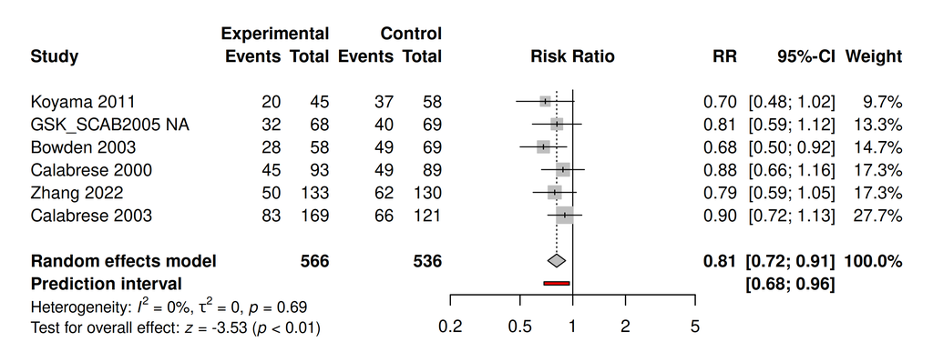

Figur 16.5: Lamotrigin prevention av bipolär episod (mani eller depression).

~8 months incidence on placebo ~50%

### 16.13.5 Lamotrigin prevention BD depression

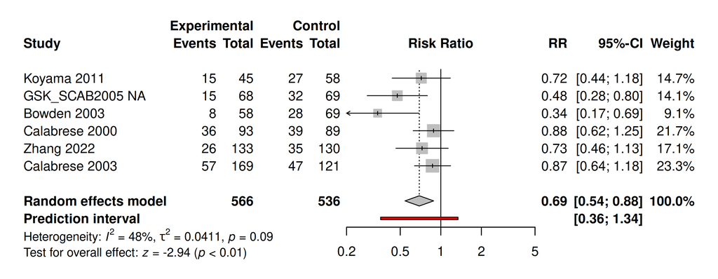

Figur 16.6: Lamotrigin prevention av bipolär depression.

~8 months incidence on placebo ~40%

### 16.13.6 Lamotrigin prevention BD mani

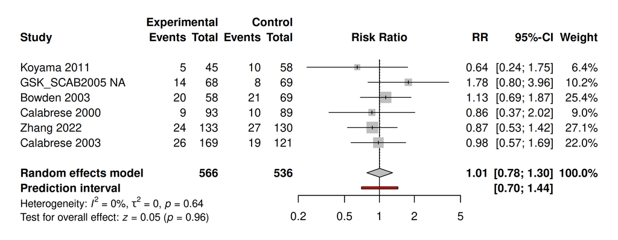

Figur 16.7: Lamotrigin prevention av mani.

~8 months incidence on placebo ~15%

### 16.13.7 Lamotrigin vid akut MDD

| Studie | N | nBP | t | Utfall | SMD (CI) | p |
| --- | --- | --- | --- | --- | --- | --- |
| Normann 2002 | 40 | 7 | 9v | HAM-D |  | NS |
| Barbosa 2003 | 23 | 8 | 6v | HAM-D |  | NS |
| Santos 2008 | 34 | 0 | 8v | MADRS | -0.16 (-0.83, 0.52) | NS |
| Barbee 2011 | 96 | 0 | 10v | MADRS | 0.13 (-0.27, 0.53) | NS |

Samtliga studier var augmentation av antidepressiva vid depressiv episod. Ref[252–255]. Se även [244].

Det finns 6 kinesiska RCT (publicerade endast på kinesiska) varav 5 visar positiva resultat.

### 16.13.8 Lamotrigin profylax MDD

Har ej hittat några studier på detta.

### 16.13.9 Sammanfattning lamotrigin vid affektiva syndrom

| Indikation | Effekt | Underlag |
| --- | --- | --- |
| Akut mani | Ingen | 2 stora opubl studier |
| Akut BP dep | Möjligen | Blandade resultat |
| Profylax BP episod | Ja |  |
| Profylax BP dep | Ja |  |
| Profylax mani | Nej(?) | För litet underlag |
| Akut MDD | Ingen | n ~ 1000, 3 opubl studier |
| Svårbeh MDD | Ingen | n = 96 |
| Profylax MDD | ? | Studier saknas |

Se [244,257,258].

### 16.13.10 Sammanfattning ungefärlig effektstorlek

| Indikation | Utfall | Placebo | Lamotrigin | Diff |
| --- | --- | --- | --- | --- |
| Akut BPD* | respons | 35% | 45% | 10% |
| Mani | respons | NS | NS | 0 |
| Profylax BP | episod 8m | 50% | 40% | 10% |
| Profylax BP | depr 8m | 40% | 30% | 10% |
| Profylax BP | mani | 15% | 15% | 0 |
| Akut MDD | respons | NS | NS | 0 |
| Sårbeh MDD* | respons | NS | NS | 0 |
| Profylax MDD | depression | ? | ? | ? |

*Osäkra resultat.

Dvs: Av 10 **med BP** som behandlas kommer 1 färre ha en depressiv episod inom 8 månader. Kanske fler över längre tid?

### 16.13.11 Guidelines lamotrigin vid BP

| Indikation | CANMAT | ISBD | BAP | NICE | WFSBP |
| --- | --- | --- | --- | --- | --- |
| Depression* | 1/2 | 1/2 | Ja/Ja | Ja/Ja | Ja/? |
| Mani |  |  |  | Nej |  |
| Profylax depr | 1/1 | 1/1 | Ja/Ja |  | 1/1 |

Monoterapi BP1/BP2. *Invändning: Blandade resultat i studier och behov av gradvis titrering.

### 16.13.12 Lamotrigin vid EIPS

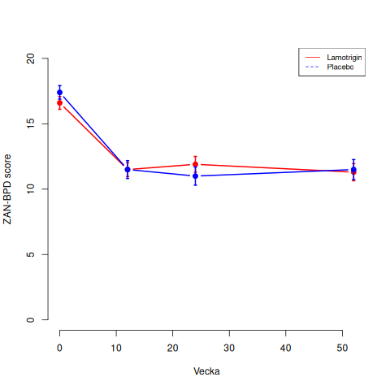

Figur 16.8: Lamotrigin vs placebo vid EIPS (medel och CI), n = 276[259].

### 16.13.13 Biverkningar av lamotrigin

Ca 70% raporterar biverkningar[245].

- Samma omfattning som placebo.
- Tex huvudvärk, illamående, sömnighet, yrsel, diarré, tremor.

Ca 10% får hudutslag (5% m placebo)

### 16.13.14 Lamotrigin hudutslag

| Behandling | Utslag | Allvarligt utslag |
| --- | --- | --- |
| Placebo | 5% |  |
| Lamotrigin | 10% | <0.1-0.3% |
| Re-challenge <4v | 36% |  |
| Re challenge >4v | 7% |  |

Se [258,260,261].

Risk för Stevens–Johnson syndrome (SJS) och toxic epidermal necrolysis (TEN): 3 på 10.000.

Lamotriginorsakade utslag debut vanligen 5 d till 2 m efter start.

Man kan försöka värdera om hudutslagen är godartade, men egentligen finns ingen tillförlitlig metod, varför rekommendationen är att alltid avsluta behandlingen och at eventuellt försöka återinsättning efter ett uppehåll på 6 månader, med mycket försiktig upptrappning.

Rating scale for dermatological drug eruptions

| Kliniska tecken | Poäng |
| --- | --- |
| Exfoliation eller erythroderma (intensiv rodnad och svullnad av huden) | 3 |
| Purpura, ömhet, blåsbildning | 1 |
| Ansikte eller slemhinnor inblandade | 1 |
| Svullna lymfkörtlar | 1 |
| Avvikande blodbild (tex eosinofili), eller stegrade levertransaminaser | 1 |
| Allmänsymtom (feber, sjukdomskänsla, ledvärk, meningism, halsont, hosta) | 1 |

0p = Benignt utslag. >2p akut bedömning (prednisolon 6 dagar nedtrappning?).

### 16.13.15 Lamotrigin titrering

| Situation | v1-2 | v3-4 | v5-6 | v7-8 | v9-10 | v11+ |
| --- | --- | --- | --- | --- | --- | --- |
| Normalt | 25 | 50 | 100→200 | 200 |  |  |
| Med valproat | 12.5* | 25 | 50→100 | 100 |  |  |
| Med karbamazepin** | 50 | 100 | 200→300 | 300 |  |  |
| Rechallenge | 5 | 10 | 15 | 20 | 25 | Norm |

Tabell: Titrering lamotrigin

(*) Ges som 25 mg vad. (**) Bör uppdelas på två doser vid 100mg+.

Om uppehåll >5d börja om titrering.

### 16.13.16 Resurser lamotrigin

[Lamotrigin patientinformation](https://www.psykiatrisydvast.se/4a85bc/globalassets/verksamheter/psykiatri/psykiatri-sydvast/pdf-er/affektiva/lamotrigin.pdf)

[Psykiatri sydväst, Lamotrigin vid bipolär sjukdom](https://www.psykiatrisydvast.se/4a85bc/globalassets/verksamheter/psykiatri/psykiatri-sydvast/pdf-er/affektiva/lamotrigin-vid-bipolar-sjd.pdf)

[Internetmedicin, läkemedelsreaktioner och hud](https://www.internetmedicin.se/hud-och-konssjukdomar/lakemedelsreaktioner-och-hud)

## 16.14 Vissa biverkningar av psykofarmaka

### 16.14.1 Arytmirisk

Se: Läkemedel som kan orsaka allvarliga rubbningar i hjärtats rytm - Fokus på förskrivning av antidepressiva och antipsykotiska läkemedel till äldre [262].

TdP1-2 kolla riskfaktorer

Crediblemeds har lista på QTT-förlängande läkemedel

Ziprasidon QTT-förlängande, även kvetiapin.

Pacher Cardiovascular Side Effects of New Antidepressants and Antipsychotics: New Drugs, old Concerns? 2004

TCAs ökar hjärtfrekvensen. De har typ I antiarrytmiska egenskaper vilket kan ge breddökning av QRS, ökat PR och QT-intervall, och AV-block. De saknar effekt på myocardkontraktilitet och kan hämma ektopisk aktivitet i förmak och kammare [154].

### 16.14.2 Antikolinerga biverkningar

#### 16.14.2.1 Antikolinerga biverkningar av antipsykotiska läkemedel

Acetylkolin är en signalsubstans i hjärnan och perifera nervsystemet. I hjärnan är acetylkolin inblandat i minne och inlärning. I andra organ ger kolinerga signaler muskelkontraktion [263].

| sign | clinical_dangers |
| --- | --- |
| Drowsiness | fatigue Risk of falling in elderly people, possibly leading to hip fracture |
| Amnesia | Disruption of daily life activities |
| Difficulty in concentrating | Difficulty in attending to daily activities and maintaining attention |
| Slowness of thought | Difficulty in comprehending information |
| Slowed or impaired psychomotor coordination | Inability to operate machinery, drive a car or participate in traffic safely |
| Loss of interest and initiative | Diminished quality of life |
| Confusion, delirium | Psychiatric sequelae |
| Reduction of REM sleep | Reduction of sleep quality |

| sign | clinical_dangers |
| --- | --- |
| Reduced salivation/dry mouth (xerostomia) | Difficulty in swallowing and talking, dental caries and oral candidiasis |
| Pupil dilatation (mydriasis) | Increased intraocular pressure |
| Loss of accommodation (cycloplegia) | Blurred vision, dizziness, unsteady gait leading to risk of falling |
| Reduced gastrointestinal motility | Constipation |
| Slowed micturition, urinary retention | Low abdominal pain |
| Reduced sweat secretion | Increased body temperature (especially at high environmental temperatures) |

Ett flertal läkemedel har antikolinerga effekter, vilket i CNS kan ge konfusion och minnesproblem. Äldre är mer känsliga för dessa effekter.

Läkemedel som saknar farmakodynamisk effekt på muskarinreceptorer kan ändå ha en pseudoantikolinerg effekt via effekter histamin H1 och alfa1-adrenerga receptorer (tex trazodon, fluvoxamin) [263].

Se Bokkapitel [264] i boken Antipsychotics and their side effects.

> Promethazine is listed as one of the drugs of highest anticholinergic activity in a study of anticholinergenic burden, including long-term cognitive impairment. Dosering vid illamående 12.5-25 mg var 4-6 tim, vid sederig 25-50 mg.

**Figur 16.9** visar en jämförelse av antikolinerg effekt för olika antipsykotiska läkemedel. Andra psykofarmaka med klinisk antikolinerg effekt inkluderar hydroxyzin, alimemazin (?), prometazin, paroxetin, tricykliska antidepressiva, och förstås biperiden [264].

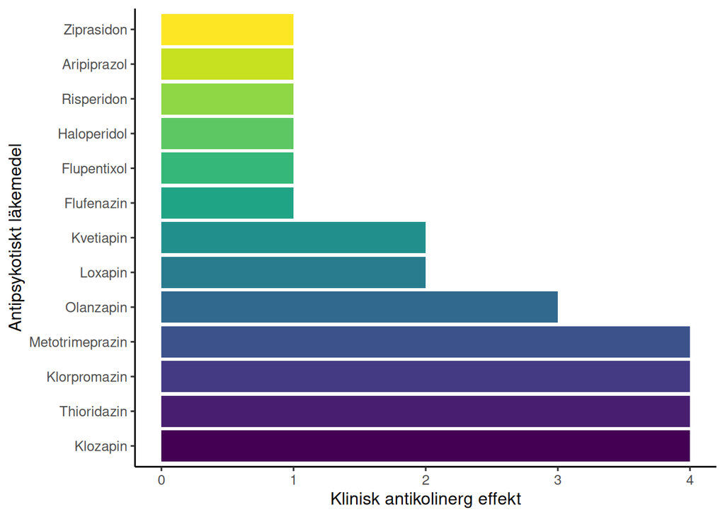

Figur 16.9: Antikolinerga effekter av antipsykotiska läkemedel [264]

Se även Stahl Clin Psychiatry 2003 Psychopharmacology of Ziprasidone[265] som innehåller figurer med olika antipsykotiska läkemedels bindingsprofiler.

Amitriptylin antikolinergt och sedarande, nortriptylin är dess metabolit som saknar dessa egenskaper.

#### 16.14.2.2 Antikolinerga effekter av antidepressiva

Främst är det de tricykliska antidepresisva som har betydande anikolinerga effekter. Inom gruppen TCA skiljer sig läkemedlen åt. Amitriptylin och doxepin har starka antikolinerga effekter, emedan tex nortriptylin har en något mindre antikolinerg effekt [263].

#### 16.14.2.3 Biverkningar kopplade till andra receptorer

Blockad av adrenerga receptorer kan ge ortostatisk hypotension och yrsel.

Viktuppgång kopplat till blockad av histamin, 5-HT2C, och acetylkolin [231, sleep].

Blockad av histaminreceptorer: Sedering, viktuppgång.

Blockad av alfa-1-receptorer: Ortostatisk hypotension.

### 16.14.3 Hudbiverkningar

**Lamotrigin:** Incidensen av allvarliga hudbiverkningar (toxisk epidermal nekrolys och Steven-Johnssons syndrom) är 0.3-1% och lägre (0.02%) vid långsam titrering [97]. Vid godartade hudutslag (uppträder hos 10%) kan läkemedlet stoppas för att sedan återintroduceras med lägre startdos (5-12.5 mg/d, alt 25 mg vad) och långsammare titrering. Godartade utslag karakteriseras av: Som värst inom några dagar och lägger sig efter 10-14 dagar; prickigt, icke-konfluerande, ej ömmande; frånvaro av systemiska symtom (tex feber, lymfadenopati, allmänpåverkan); involverar ej mukösa membran (mun, läppar, ögon), normala labbprover (blodstatus, leverstatus, kreatinin, urinsticka). Utslag som uppträder inom 5 dagar är troligen ej läkemedelsrelaterade [117].

**Karbamazepin:** Kan orsaka SJS men extremt låg incidens. Uppträder i så fall vanligen inom åtta veckor [97].

**Valproat:** Hudbiverkningar enligt ovan förekommer, men ectremt låg risk [97].

**Litium:** Hudbiverkningar hos 3-45% beroende på kriterier. Acne, psoriasis, eksem, håravfall, hidradenitis suppurativa, nageldystrofi, lesioner i mukösa membran [97].

### 16.14.4 Inverkan på kramptröskel

ECT kan vara antikonvulsivt [50]. Beakta möjliga interaktioner med antiepileptiska medel [266].

#### 16.14.4.1 Antidepressiva [50]

- Låg risk vid epilepsi: SSRI (beakta dock interaktioner, överväg escitalopram), mirtazapin.
- Sannolikt låg risk (begränsade data): Agomelatin, duloxetin, vortioxetin, MAOi.
- Måttlig risk: Litium, vanlafaxin.
- Högre risk: Bupropion, TCA.

#### 16.14.4.2 Antipsykotiska [50]

- Låg risk: Aripiprazol, ziprasidon, haloperidol, flupentixol, fluphenazin, risperidon.
- Sannolikt låg risk (begränsade data): Asenapi, brexipiprazol, kariprazin, lurasidon.
- Måttlig risk: Olanzapin, kvetiapin.
- Högre risk: Klozapin (använd med försiktighet), klorpromazin, loxepin

Risperidon samma effekt som placebo på kramptröskeln.

Försiktighet (undvik?) med depotinjektioner då de ej kan avslutas snabbt.

#### 16.14.4.3 ADHD-läkemedel [50]

- Låg risk: Metylfenidat
- Sannolikt låg risk (begränsade data): Amfetaminer, atomoxetin.

## 16.15 Beskrivning av vissa läkemedel

**Biperiden** (Akineton^®): Centralt verkande antikolinergt läkemedel. Peroralt ges 1-2(–4) mg 1–4 gånger dagligen. Vid parenteral medicinering (akut dystoni) ges 2.5–5 mg intramuskulärt eller långsamt intravenöst. Vid behov kan dosen upprepas efter 30 minuter. Försiktighet till äldre, vid prostatahypertrofi, förhöjd krampbenägenhet, och takykardi.

## 16.16 Beskrivning av vissa biverkningar

**Hyperhidros** (svettningar) förekommer som kolinerg biverkan av exempelvis duloxetin. Kan behandlas med oxybutynin (off-label), som enligt NICE har effekt mot svettningarna och kan i sin tur vara associerat med antikolinerga biverkningar såsom muntorrhet, urinretention och förstoppning (https://www.nice.org.uk/advice/es10/resources/hyperhidrosis-oxybutynin-pdf-1158108623557). Oxybutynin är kontraindicerat vid galukom, vissa gastrointestinala sjukdomar, urinretention och myastenia gravis.

**Ökad blödningsrisk** hos medel som hämmar serotonintransportören, dvs SSRI, beroende på att denna finns även i blodplättarna. Bör tas hänsyn till om patienten tar antikoagulantia eller trombocythämmare.

**QT-tidsförlängning** kan orsakas av olika läkemedelsgrupper såsom vissa antibiotika, antidepressiva, och antipsykotiska läkemedel. Det kan leda till ventrikelarytmi av typen Torsade de Point. Se [crediblemeds.org](https://crediblemeds.org/) för riskklassificering av olika läkemedel avseende arytmirisk. Se även socialstyrelsens dokument om TdP [262]. Ett [QT-nomogram](https://www.researchgate.net/figure/QT-nomogram-QT-HR-pairs-are-plotted-and-if-they-are-above-the-line-they-are_fig1_272517446) kan användas för att avgöra när QT-tiden är riskabelt förlängd. Se avsnitt 16.16.1 för mer information om arytmirisk.

### 16.16.1 TdP

Olika psykotropa läkemedel medför varierande risk för Torsade de Point (TdP), vilket är en allvarlig arytmi.

Några riskfaktorer för TdP [262]:

- Ålder > 65 år
- Kvinna
- Samtidig annat TdP-preparat
- Interaktion som ökar plasmakoncentrationen
- Hjärtsjukdom
  - Aortastenos [267]
  - Bradycardi, AV-block [267]
- Njur- eller leversjukdom
- Endokrin sjukdom
  - Hypothyroidism [267]
  - Hypoparathyroidism [267]
- Elektrolytrubbningar
  - Hypokalemi, hypomagnesemi eller hypocalcemi.
  - Diuretika kan ge lågt kalium; PPI kan ge lågt magnesium.
- Övrigt
  - D-vitaminbrist [267]
  - Överdrivet lakritsintag [267]

Om två eller fler riskfaktorer föreligger rekommenderas EKG före och efter insättning [262]. Om QTc > 459 mm (alternativt använd [ett QT-nomogram](https://www.researchgate.net/figure/QT-nomogram-QT-HR-pairs-are-plotted-and-if-they-are-above-the-line-they-are_fig1_272517446)) bör man välja icke-TdP-läkemedel. QT-nomogrammet kan vara mer förlåtande.

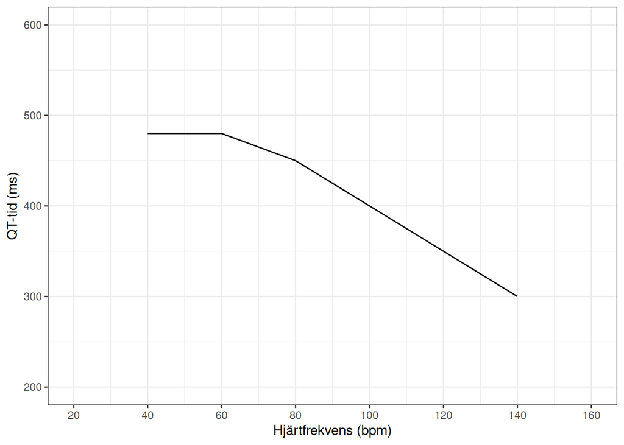

Figur 16.10: QT-nomogram. Para ihop QTT med hjärtfrekvens. Om intersektionen är över linjen föreligger risk för TdP.

Läkemedel kan klassificeras utifrån risken att de orsakar TdP i sk TdP-klasser:

- Fastställd risk för hjärtarytmi: TdP 1
- Misstänkt risk för hjärtarytmi: TdP2
- Fastställd risk i vissa situationer för hjärtarytmi: TdP 3
- Utan känd risk: TdP 0. Kan innebära att risken är okänd pga att data saknas.

Observera att TdP1 betecknar högre risk än TdP3 men att TdP0 betyder ingen känd risk. Se [crediblemeds.org](https://crediblemeds.org/) för listor med riskklassificering av olika läkemedel.

För personer som använder TdP-klassade läkemedel bör elektrolyter kontrolleras vid tex diarre och vid användning av diuretika eller protonpumpshämmare.

Tabell: TdP-klassificering av antidepressiva

| Tdp1 | Tdp2 | Tdp3 |
| --- | --- | --- |
| Citalopram | Mirtazapin | Amitriptylin |
| Escitalopram | Venlafaxin | Fluoxetin |
|  | Imipramin | Paroxetin |
|  | Klomipramin | Sertralin |
|  | Nortriptylin | Trimipramin |
|  | Maprotilin | Fluvoxamin |

Följende läkemedel är klassade som TdP0: agomelatin, bupropion, duloxetin, fenelzin, lofepramin, mianserin, moklobemid, nefazodon, reboxetin, trancylcypromin, tryptofan. Data är från 2020 och kan vara inaktuell när ny kunskap tillkommer.

Tabell: TdP-klassning av antipsykotiska

| Tdp1 | Tdp2 | Tdp3 |
| --- | --- | --- |
| Droperidol | Aripiprazol | Kvetiapin |
| Haloperidol | Klozapin | Ziprasidon |
| Klorpromazin | Litium |  |
| Pimozid | Olanzapin |  |
| Sulpirid | Paliperidon |  |
| Tioridazin | Risperidon |  |
|  | Flupentixol |  |
|  | Levomepromazin |  |
|  | Melperon |  |
|  | Perfenazin |  |
|  | Zuklopentixol |  |

Följende läkemedel är klassade som TdP0: flufenazin, klorprotixen, periciazin, proklorperazin. Data är från 2020 och kan vara inaktuell när ny kunskap tillkommer.